# Pertemuan 1

# Library

```r
library(forecast)
```

```r
library(graphics)
library(TTR)
library(TSA)
library (rio)
library(ggplot2)
```

# DATA

## Impor Data

```r
# Baca Data
data1 <- read.csv("ispu_anggota_3.csv")

# Menampilkan 5 data pertama
head(data1)
```

```
##      tanggal            stasiun pm25 pm10 so2 co o3 no2 max critical categori
## 1 2021-04-20 DKI1 (Bunderan HI)   83   56  25 12 21  30  83     PM25   SEDANG
## 2 2021-04-21 DKI1 (Bunderan HI)   87   63  24 19 14  37  87     PM25   SEDANG
## 3 2021-04-22 DKI1 (Bunderan HI)   81   54  25 14 23  40  81     PM25   SEDANG
## 4 2021-04-23 DKI1 (Bunderan HI)   99   66  25 16 21  42  99     PM25   SEDANG
## 5 2021-04-24 DKI1 (Bunderan HI)   99   66  23 18 30  40  99     PM25   SEDANG
## 6 2021-04-25 DKI1 (Bunderan HI)   86   63  24 15 17  36  86     PM25   SEDANG
```

## Eksplorasi Data

```r
View (data1) # menampilkan data dalam bentuk tabel
str(data1) # menampilkan struktur data
```

```
## 'data.frame':    112 obs. of  11 variables:
##  $ tanggal : chr  "2021-04-20" "2021-04-21" "2021-04-22" "2021-04-23" ...
##  $ stasiun : chr  "DKI1 (Bunderan HI)" "DKI1 (Bunderan HI)" "DKI1 (Bunderan HI)" "DKI1 (Bunderan HI)" ...
##  $ pm25    : num  83 87 81 99 99 86 79 94 77 71 ...
##  $ pm10    : num  56 63 54 66 66 63 56 62 54 57 ...
##  $ so2     : num  25 24 25 25 23 24 26 26 21 23 ...
##  $ co      : num  12 19 14 16 18 15 10 12 15 17 ...
##  $ o3      : num  21 14 23 21 30 17 22 23 21 18 ...
##  $ no2     : num  30 37 40 42 40 36 24 28 34 38 ...
##  $ max     : num  83 87 81 99 99 86 79 94 77 71 ...
##  $ critical: chr  "PM25" "PM25" "PM25" "PM25" ...
##  $ categori: chr  "SEDANG" "SEDANG" "SEDANG" "SEDANG" ...
```

```r
dim(data1) # menampilkan dimensi data
```

```
## [1] 112  11
```

Data Indeks Standar Kualitas Udara (ISPU) terdiri dari 11 variabel yaitu tanggal, stasiun, PM25, PM10, $SO_2$, $CO$, $O_3$, $NO_2$, max, critical, dan categori. Data ini memiliki 112 observasi yang berasal dari stasiun DKI1 (Bunderan HI), tercatat mulai tanggal 20 April 2021 sampai 21 Maret 2023. Namun kami (kelompok 3) memilih PM10 sebagai variabel utamanya.

```r
data1.ts <- ts(data1$pm10)
```

## Ringkasan Data

```r
summary(data1.ts)
```

```
##    Min. 1st Qu.  Median    Mean 3rd Qu.    Max.
##   40.00   52.75   56.00   57.62   63.00   75.00
```

Berdasarkan hasil statistik deskriptif, nilai PM10 memiliki rata-rata sebesar 57,62 dengan median 56,00. Nilai PM10 berkisar antara 40,00 hingga 75,00, dengan 50% data berada pada rentang 52,75–63,00. Hal ini menunjukkan bahwa konsentrasi PM10 pada periode pengamatan cenderung berada di sekitar nilai 57,62.

## Plot Data Deret Waktu

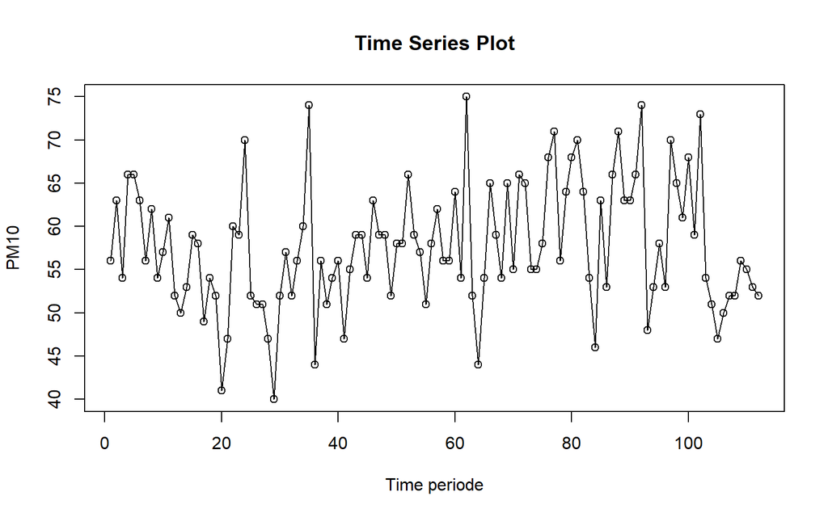

```r
ts.plot(data1.ts, xlab="Time periode", ylab="PM10",
        main = "Time Series Plot")
points(data1.ts)
```

Berdasarkan plot deret waktu, terlihat bahwa nilai PM10 berfluktuasi di sekitar rentang 40 hingga 75 (di sekitar nilai rata-ratana) sepanjang periode pengamatan, sehingga dapat diindikasikan bahwa data ini bersifat relatif stasioner dan tidak menunjukkan pola musiman yang mencolok maupun tren jangka panjang yang konsisten.

# Single Moving Average (SMA) & Double Moving Average (DMA)

## Pembagian Data

```r
# hitung jumlah data
n <- nrow(data1)

# tentukan batas 80%
n_train <- floor(0.8 * n)

# hitung banyak data yang masuk ke data uji (testing)
n_test  <- n - n_train

# bagi data
training_ma <- data1[1:n_train, ]
testing_ma  <- data1[(n_train+1):n, ]

# ubah ke time series
train_ma.ts <- ts(training_ma$pm10)
test_ma.ts  <- ts(testing_ma$pm10)
```

## Eksplorasi Keseluruhan Data

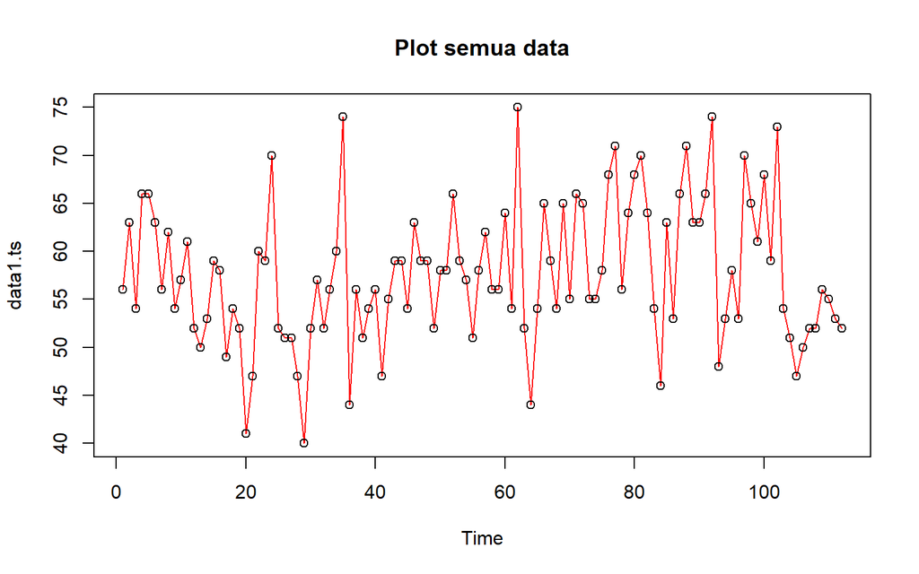

```r
plot(data1.ts, col="red",main="Plot semua data")
points(data1.ts)
```

Pola yang terlihat sama seperti sebelumnya, yaitu data berfluktuasi di kisaran 40 hingga 75 tanpa tren naik/turun yang konsisten, sehingga data ini cenderung bersifat stasioner dan cocok untuk dianalisis menggunakan metode-metode pemulusan seperti SMA, DMA, SES, maupun DES.

## Eksplorasi Data Latih

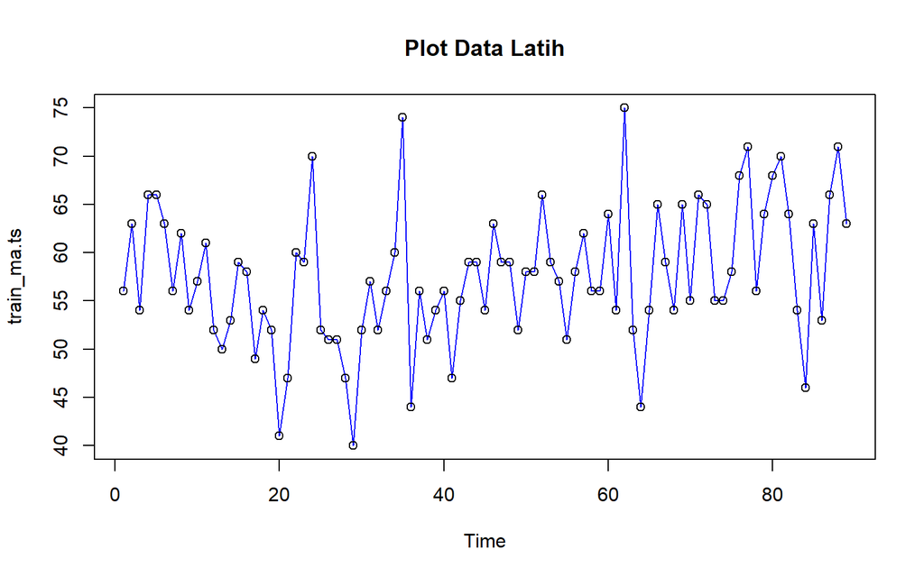

```r
plot(train_ma.ts, col="blue",main="Plot Data Latih")
points(train_ma.ts)
```

Plot Data Latih terdiri dari 89 observasi yang menunjukkan pola fluktuatif sehingga cocok menjadi dasar bagi model sebelum dilakukan peramalan.

## Eksplorasi Data Uji

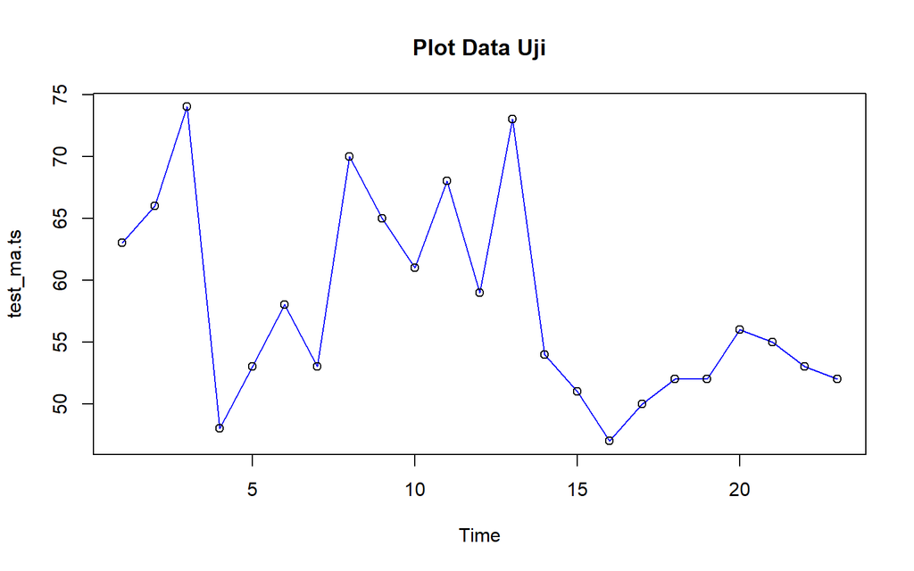

```r
plot(test_ma.ts, col="blue",main="Plot Data Uji")
points(test_ma.ts)
```

Plot Data Uji terdiri dari 23 observasi dengan kemiripan pola seperti data latih ini menunjukkan bahwa pembagian data telah representatif, sehingga hasil evaluasi akurasi pada data uji dapat mencerminkan kemampuan model secara wajar.

## Eksplorasi dengan GGPLOT2

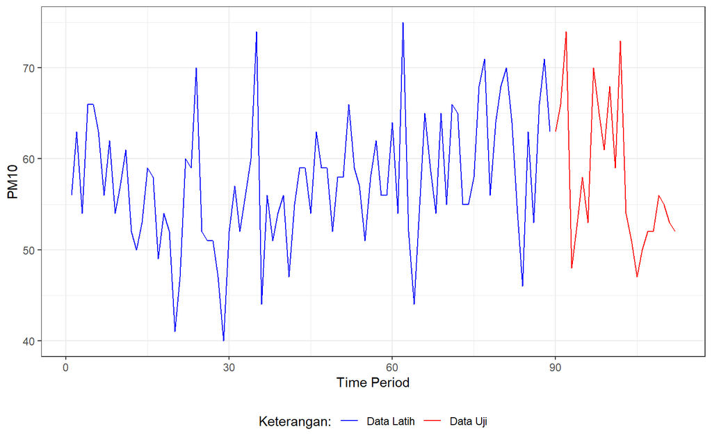

```r
ggplot() +
  geom_line(data = training_ma, aes(x = seq_len(nrow(training_ma)), y = pm10, col = "Data Latih")) +
  geom_line(data = testing_ma, aes(x = n_train + seq_len(nrow(testing_ma)), y = pm10, col = "Data Uji")) +
  labs(x = "Time Period", y = "PM10", color = "Legend") +
  scale_colour_manual(name="Keterangan:", breaks = c("Data Latih", "Data Uji"),values = c("blue", "red")) +
  theme_bw() + theme(legend.position = "bottom",
  plot.caption = element_text(hjust=0.5, size=12))
```

# Single Moving Average (SMA)

Single Moving Average (SMA) adalah data suatu periode dipengaruhi oleh data periode sebelumnya. Metode pemulusan ini cocok digunakan untuk pola data stasioner atau konstan. Prinsip dasar metode pemulusan ini adalah data pemulusan pada periode ke-t merupakan rata rata dari m buah data pada periode ke-t hingga periode ke ($t-m+1$).

$$S_t = \frac{1}{m} \sum_{i=t-m+1}^{t}
X_i$$
Data pemulusan pada periode ke-t selanjutnya digunakan sebagai nilai peramalan pada periode ke $t+1$.
$$F_t =
S_{t-1}, F_{n,h} = S_n$$
Pemulusan menggunakan metode SMA dilakukan dengan fungsi SMA(). Dalam hal ini akan dilakukan pemulusan dengan parameter m=7.

```r
data.sma<-SMA(train_ma.ts, n=7)
data.sma
```

```
## Time Series:
## Start = 1
## End = 89
## Frequency = 1
##  [1]       NA       NA       NA       NA       NA       NA 60.57143 61.42857
##  [9] 60.14286 60.57143 59.85714 57.85714 56.00000 55.57143 55.14286 55.71429
## [17] 54.57143 53.57143 53.57143 52.28571 51.42857 51.57143 51.71429 54.71429
## [25] 54.42857 54.28571 55.71429 55.71429 52.85714 51.85714 50.00000 50.00000
## [33] 50.71429 52.00000 55.85714 56.42857 57.00000 56.14286 56.42857 56.42857
## [41] 54.57143 51.85714 54.00000 54.42857 54.85714 56.14286 56.57143 58.28571
## [49] 57.85714 57.71429 57.57143 59.28571 58.71429 58.42857 57.28571 58.14286
## [57] 58.71429 58.42857 57.00000 57.71429 57.28571 60.71429 59.85714 57.28571
## [65] 57.00000 58.28571 57.57143 57.57143 56.14286 56.57143 59.71429 61.28571
## [73] 59.85714 59.28571 59.85714 60.28571 62.57143 61.14286 61.00000 62.85714
## [81] 65.00000 65.85714 63.85714 60.28571 61.28571 59.71429 59.42857 59.57143
## [89] 59.42857
```

Data pemulusan pada periode ke-t selanjutnya digunakan sebagai nilai peramalan pada periode ke $t+1$ sehingga hasil peramalan 1 periode kedepan adalah sebagai berikut.

```r
data.ramal<-c(NA,data.sma)
data.ramal # forecast 1 periode ke depan
```

```
##  [1]       NA       NA       NA       NA       NA       NA       NA 60.57143
##  [9] 61.42857 60.14286 60.57143 59.85714 57.85714 56.00000 55.57143 55.14286
## [17] 55.71429 54.57143 53.57143 53.57143 52.28571 51.42857 51.57143 51.71429
## [25] 54.71429 54.42857 54.28571 55.71429 55.71429 52.85714 51.85714 50.00000
## [33] 50.00000 50.71429 52.00000 55.85714 56.42857 57.00000 56.14286 56.42857
## [41] 56.42857 54.57143 51.85714 54.00000 54.42857 54.85714 56.14286 56.57143
## [49] 58.28571 57.85714 57.71429 57.57143 59.28571 58.71429 58.42857 57.28571
## [57] 58.14286 58.71429 58.42857 57.00000 57.71429 57.28571 60.71429 59.85714
## [65] 57.28571 57.00000 58.28571 57.57143 57.57143 56.14286 56.57143 59.71429
## [73] 61.28571 59.85714 59.28571 59.85714 60.28571 62.57143 61.14286 61.00000
## [81] 62.85714 65.00000 65.85714 63.85714 60.28571 61.28571 59.71429 59.42857
## [89] 59.57143 59.42857
```

```r
data.gab <- cbind(
  aktual    = c(data1.ts),
  pemulusan = c(data.sma, rep(NA, n - length(data.sma))),
  ramalan   = c(data.ramal, rep(data.ramal[length(data.ramal)], n -length(data.ramal)))
)
data.gab #forecast 24 periode ke depan
```

```
##        aktual pemulusan  ramalan
##   [1,]     56        NA       NA
##   [2,]     63        NA       NA
##   [3,]     54        NA       NA
##   [4,]     66        NA       NA
##   [5,]     66        NA       NA
##   [6,]     63        NA       NA
##   [7,]     56  60.57143       NA
##   [8,]     62  61.42857 60.57143
##   [9,]     54  60.14286 61.42857
##  [10,]     57  60.57143 60.14286
##  [11,]     61  59.85714 60.57143
##  [12,]     52  57.85714 59.85714
##  [13,]     50  56.00000 57.85714
##  [14,]     53  55.57143 56.00000
```

[output cut: 98 more lines]

## Plot Data Deret Waktu Hasil Peramalan

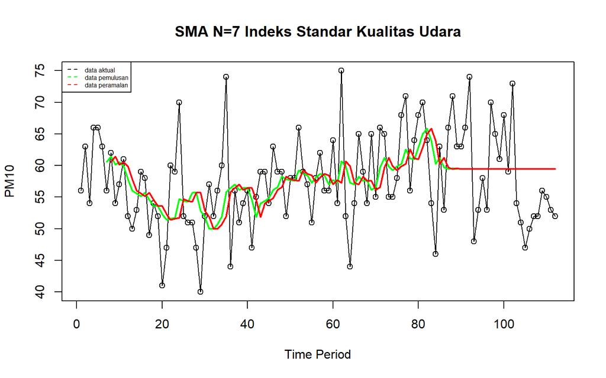

```r
ts.plot(data1.ts, xlab="Time Period", ylab="PM10", main= "SMA N=7 Indeks Standar Kualitas Udara")
points(data1.ts)
lines(data.gab[,2],col="green",lwd=2)
lines(data.gab[,3],col="red",lwd=2)
legend("topleft",c("data aktual","data pemulusan","data peramalan"), lty=8, col=c("black","green","red"), cex=0.5)
```

Garis hijau (data pemulusan) mengikuti pergerakan data aktual dengan cukup baik selama periode data latih, meskipun tidak dapat menangkap lonjakan-lonjakan tajam (puncak/lembah ekstrem) karena sifat Single Moving Average (SMA) yang merata-ratakan nilai sehingga cenderung “meredam” fluktuasi. Pada periode data uji (garis merah setelah periode ke-89), hasil ramalan bersifat konstan/datar, sesuai dengan karakteristik **metode SMA yang hanya mampu meramalkan satu nilai tetap ke depan untuk seluruh periode ramalan berikutnya**. Hal ini menunjukkan bahwa SMA kurang responsif terhadap fluktuasi data yang terjadi pada periode data uji.

## Sum Squares Error (SSE), Mean Square Error (MSE) dan Mean Absolute Percentage Error (MAPE)

$$SSE = \sum_{t=1}^{n} (y_t -
\hat{y}_t)^2$$
$$MSE = \frac{1}{n}
\sum_{t=1}^{n} (y_t - \hat{y}_t)^2$$
$$MAPE = \frac{1}{n} \sum_{t=1}^{n} \left|
\frac{y_t - \hat{y}_t}{y_t} \right| * 100$$

## Akurasi Data Latih

```r
error_train.sma = train_ma.ts-data.ramal[1:length(train_ma.ts)]

SSE_train.sma = sum(error_train.sma[8:length(train_ma.ts)]^2)
MSE_train.sma = mean(error_train.sma[8:length(train_ma.ts)]^2)
MAPE_train.sma = mean(abs((error_train.sma[8:length(train_ma.ts)]/train_ma.ts[8:length(train_ma.ts)])*100))

akurasi_train.sma <- matrix(c(SSE_train.sma, MSE_train.sma, MAPE_train.sma))
row.names(akurasi_train.sma)<- c("SSE", "MSE", "MAPE")
colnames(akurasi_train.sma) <- c("Akurasi m = 7")
akurasi_train.sma
```

```
##      Akurasi m = 7
## SSE     4615.71429
## MSE       56.28920
## MAPE      10.40972
```

Dalam hal ini nilai MAPE data latih pada metode pemulusan SMA sekitar 10,41%, nilai ini dapat dikategorikan sebagai nilai akurasi yang baik (berada pada rentang 10%–20%). Selanjutnya dilakukan perhitungan nilai MAPE data uji pada metode pemulusan SMA.

## Akurasi Data Uji

```r
error_test.sma = test_ma.ts - data.gab[(n_train+1):n, "ramalan"]

SSE_test.sma = sum(error_test.sma^2)
MSE_test.sma = mean(error_test.sma^2)
MAPE_test.sma = mean(abs((error_test.sma/test_ma.ts*100)))

akurasi_test.sma <- matrix(c(SSE_test.sma, MSE_test.sma, MAPE_test.sma))
row.names(akurasi_test.sma)<- c("SSE", "MSE", "MAPE")
colnames(akurasi_test.sma) <- c("Akurasi m = 7")
akurasi_test.sma
```

```
##      Akurasi m = 7
## SSE     1468.79592
## MSE       63.86069
## MAPE      12.39398
```

Perhitungan akurasi menggunakan data uji menghasilkan nilai MAPE sebesar 12,39% sehingga nilai akurasi ini dapat dikategorikan sebagai baik (berada pada rentang 10%–20%).

# Double Moving Average (DMA)

Double Moving Average (DMA) lebih cocok digunakan untuk pola data trend. Proses pemulusan dengan rata rata dalam metode ini dilakukan sebanyak 2 kali.

Tahap 1:
$$S_{1,t} = \frac{1}{m}
\sum_{i=t-m+1}^{t} X_i$$
Tahap 2:
$$S_{2,t} = \frac{1}{m} \sum_{i=t-m+1}^{t}
S_{1,i}$$
Forecast $h$ langkah ke depan dihitung dengan cara:
$$F_{2,t,t+h}
= A_t + B_t(h)$$
dengan komponen level ($A_t$) dan tren ($B_t$):
$$A_t =
2S_{1,t} - S_{2,t} \quad \text{dan} \quad B_t = \frac{2}{m-1}(S_{1,t} -
S_{2,t})$$

```r
dma <- SMA(data.sma, n = 7)
At <- 2*data.sma - dma
Bt <- 2/(7-1)*(data.sma - dma)
data.dma <- At + Bt
data.ramal2 <- c(NA, data.dma)

t = 1:n_test
f = c()
for (i in t) {
  f[i] = At[length(At)] + Bt[length(Bt)]*(i)
}

data.gab2 <- cbind(
  aktual     = c(data1.ts),
  pemulusan1 = c(data.sma, rep(NA, n - length(data.sma))),
  pemulusan2 = c(dma, rep(NA, n - length(dma))),
  At = c(At, rep(NA, n - length(At))),
  Bt = c(Bt, rep(NA, n - length(Bt))),
  ramalan = c(data.ramal2, f[-1])
)
data.gab2
```

```
##        aktual pemulusan1 pemulusan2       At            Bt  ramalan
##   [1,]     56         NA         NA       NA            NA       NA
##   [2,]     63         NA         NA       NA            NA       NA
##   [3,]     54         NA         NA       NA            NA       NA
##   [4,]     66         NA         NA       NA            NA       NA
##   [5,]     66         NA         NA       NA            NA       NA
##   [6,]     63         NA         NA       NA            NA       NA
##   [7,]     56   60.57143         NA       NA            NA       NA
##   [8,]     62   61.42857         NA       NA            NA       NA
##   [9,]     54   60.14286         NA       NA            NA       NA
##  [10,]     57   60.57143         NA       NA            NA       NA
##  [11,]     61   59.85714         NA       NA            NA       NA
##  [12,]     52   57.85714         NA       NA            NA       NA
##  [13,]     50   56.00000   59.48980 52.51020 -1.163265e+00       NA
##  [14,]     53   55.57143   58.77551 52.36735 -1.068027e+00 51.34694
```

[output cut: 98 more lines]

## Visualisasi Pemulusan DMA

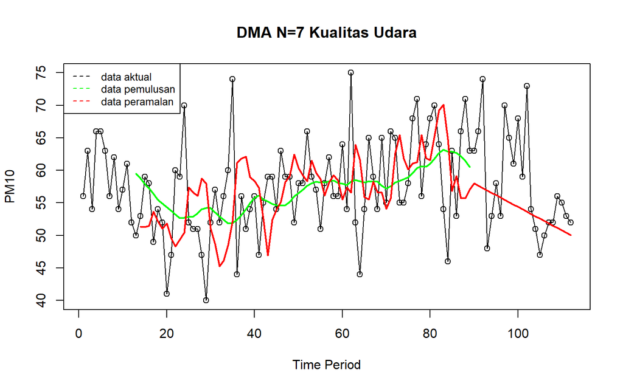

```r
ts.plot(data1.ts, xlab="Time Period", ylab="PM10", main= "DMA N=7 Kualitas Udara")
points(data1.ts)
lines(data.gab2[,3],col="green",lwd=2)
lines(data.gab2[,6],col="red",lwd=2)
legend("topleft",c("data aktual","data pemulusan","data peramalan"), lty=8, col=c("black","green","red"), cex=0.8)
```

Garis pemulusan (hijau) mengikuti pergerakan data aktual dengan cukup baik pada periode data latih, meskipun belum mampu menangkap fluktuasi ekstrem akibat proses perataan ganda pada metode DMA. Pada periode data uji, hasil ramalan (garis merah) menunjukkan pola tren menurun, sesuai dengan karakteristik metode DMA yang memperhitungkan komponen tren dalam peramalannya. Namun demikian, karena data aktual pada periode uji tidak menunjukkan tren yang konsisten, hasil ramalan tersebut berpotensi menghasilkan tingkat kesalahan yang cukup besar.

## Sum Squares Error (SSE), Mean Square Error (MSE) dan Mean Absolute Percentage Error (MAPE)

$$SSE = \sum_{t=1}^{n} (y_t -
\hat{y}_t)^2$$
$$MSE = \frac{1}{n}
\sum_{t=1}^{n} (y_t - \hat{y}_t)^2$$
$$MAPE = \frac{1}{n} \sum_{t=1}^{n} \left|
\frac{y_t - \hat{y}_t}{y_t} \right| * 100$$

## Akurasi Data Latih

```r
error_train.dma = train_ma.ts-data.ramal2[1:length(train_ma.ts)]
SSE_train.dma = sum(error_train.dma[14:length(train_ma.ts)]^2)
MSE_train.dma = mean(error_train.dma[14:length(train_ma.ts)]^2)
MAPE_train.dma = mean(abs((error_train.dma[14:length(train_ma.ts)]/train_ma.ts[14:length(train_ma.ts)])*100))
akurasi_train.dma <- matrix(c(SSE_train.dma, MSE_train.dma, MAPE_train.dma))

row.names(akurasi_train.dma)<- c("SSE", "MSE", "MAPE")
colnames(akurasi_train.dma) <- c("Akurasi m = 7")
akurasi_train.dma
```

```
##      Akurasi m = 7
## SSE     6074.03651
## MSE       79.92153
## MAPE      12.90273
```

Perhitungan akurasi pada data latih menggunakan nilai MAPE menghasilkan nilai MAPE sebesar 12,90% sehingga dikategorikan baik (sekitar 10-20%). Selanjutnya, perhitungan nilai akurasi dilakukan pada data uji.

## Akurasi Data Uji

```r
error_test.dma = test_ma.ts - data.gab2[(n_train+1):n, "ramalan"]
SSE_test.dma = sum(error_test.dma^2)
MSE_test.dma = mean(error_test.dma^2)
MAPE_test.dma = mean(abs((error_test.dma/test_ma.ts*100)))

akurasi_test.dma <- matrix(c(SSE_test.dma, MSE_test.dma, MAPE_test.dma))
row.names(akurasi_test.dma)<- c("SSE", "MSE", "MAPE")
colnames(akurasi_test.dma) <- c("Akurasi m = 7")
akurasi_test.dma
```

```
##      Akurasi m = 7
## SSE    1503.758897
## MSE      65.380822
## MAPE      9.817631
```

Perhitungan akurasi menggunakan data uji menghasilkan nilai MAPE yang kurang dari 10% sehingga nilai akurasi ini dapat dikategorikan sebagai sangat baik.

Pada data latih, metode SMA lebih baik dibandingkan dengan metode DMA, sedangkan pada data uji, metode DMA lebih baik dibandingkan SMA.

# Single Exponential Smoothing (SES) & Double Exponential Smoothing (DES)

Metode Exponential Smoothing merupakan metode pemulusan deret waktu dengan memberikan bobot yang menurun secara eksponensial pada data historis, di mana nilai terbaru mendapat bobot lebih besar dibanding nilai yang lebih lama. Metode ini menggunakan satu atau lebih parameter pemulusan yang secara langsung menentukan besar kecilnya bobot setiap pengamatan. Pemilihan parameter yang tepat akan sangat berpengaruh terhadap hasil ramalan. Secara umum, Exponential Smoothing dibedakan menjadi dua jenis, yaitu model tunggal (single) yang digunakan untuk data tanpa tren maupun musiman, serta model ganda (double) yang mampu menangkap adanya tren pada data.

## Pembagian Data

Pembagian data dilakukan dengan perbandingan 80% data latih dan 20% data uji.

```r
# jumlah baris data
n <- nrow(data1)

# hitung batas 80%
n_train <- floor(0.8 * n)

# bagi data
training <- data1[1:n_train, ]
testing  <- data1[(n_train+1):n, ]

# ubah ke time series
train.ts <- ts(training$pm10)
test.ts  <- ts(testing$pm10)
```

## Eksplorasi Data

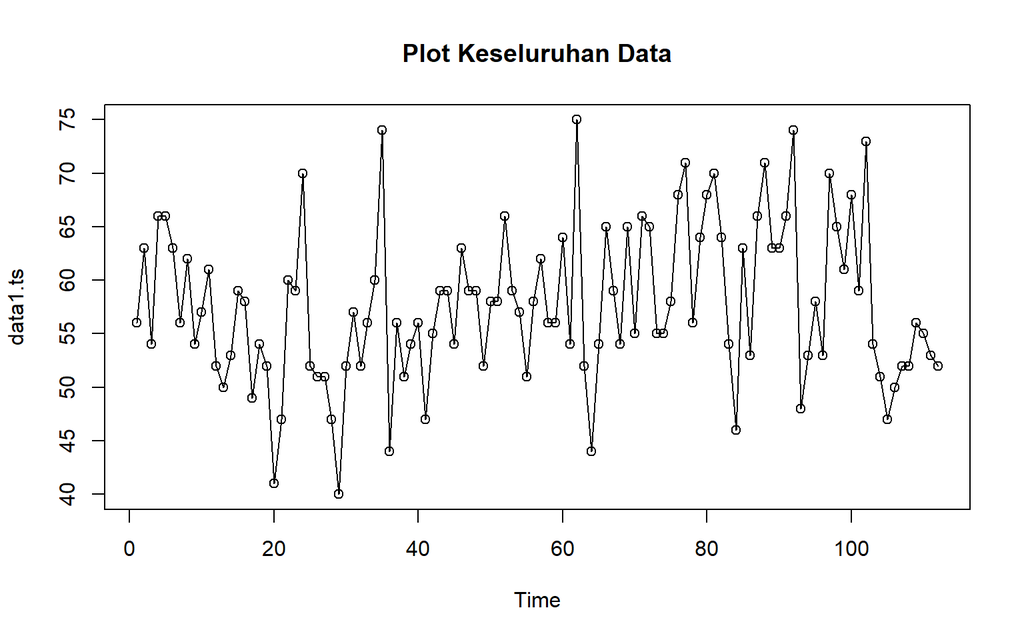

```r
# eksplorasi keseluruhan data
plot(data1.ts, col="black",main="Plot Keseluruhan Data")
points(data1.ts)
```

Pola data terlihat berfluktuasi di kisaran 40 hingga 75 tanpa menunjukkan tren naik/turun yang konsisten maupun pola musiman yang jelas, sehingga data ini cenderung bersifat stasioner dan sesuai dengan karakteristik data yang cocok dianalisis menggunakan metode SES.

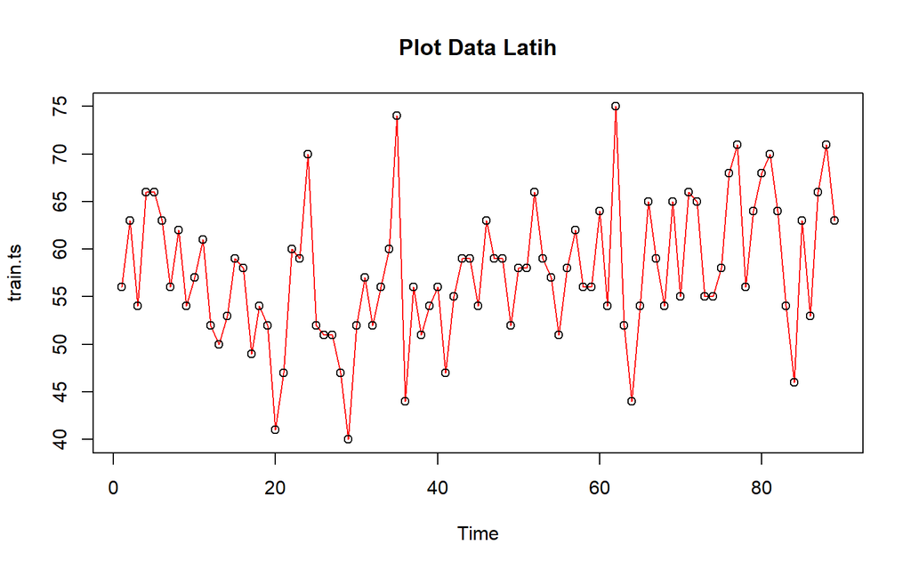

```r
# eksplorasi data latih
plot(train.ts, col="red",main="Plot Data Latih")
points(train.ts)
```

Plot data latih (89 observasi) menunjukkan pola fluktuatif yang sama dengan keseluruhan data, bergerak di kisaran 40 hingga 75 tanpa tren naik/turun yang jelas. Karakteristik data yang relatif stasioner ini sesuai dengan asumsi metode SES, yang memang dirancang untuk data tanpa tren maupun pola musiman.

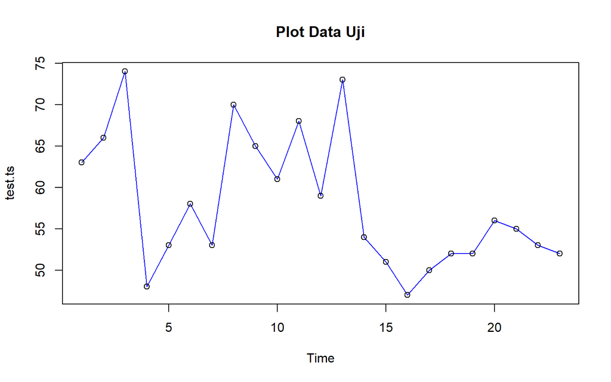

```r
# eksplorasi data uji
plot(test.ts, col="blue",main="Plot Data Uji")
points(test.ts)
```

Plot data uji (23 observasi) ini menunjukkan pola fluktuatif yang serupa dengan data latih, bergerak di kisaran 45 hingga 75 tanpa tren yang konsisten. Kemiripan pola antara data latih dan data uji ini menunjukkan bahwa pembagian data telah representatif, sehingga model SES yang dibangun dari data latih diharapkan dapat diuji secara wajar menggunakan data uji ini.

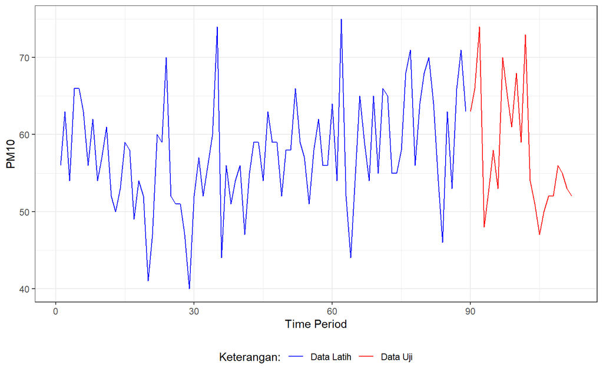

```r
# eksplorasi dengan GGPLOT
ggplot() +
  geom_line(data = training_ma, aes(x = seq_len(nrow(training_ma)), y = pm10, col = "Data Latih")) +
  geom_line(data = testing_ma, aes(x = n_train + seq_len(nrow(testing_ma)), y = pm10, col = "Data Uji")) +
  labs(x = "Time Period", y = "PM10", color = "Legend") +
  scale_colour_manual(name="Keterangan:", breaks = c("Data Latih", "Data Uji"),
                      values = c("blue", "red")) +
  theme_bw() + theme(legend.position = "bottom", plot.caption = element_text(hjust=0.5, size=12))
```

# Single Exponential Smoothing (SES)

Single Exponential Smoothing (SES) adalah metode peramalan deret waktu yang dikembangkan untuk mengatasi kelemahan Moving Average. Single Exponential Smoothing merupakan metode pemulusan yang tepat digunakan untuk data dengan pola stasioner atau konstan. Nilai pemulusan pada periode ke-t didapat dari persamaan:

$$\tilde{y}_T = \lambda y_t + (1 -
\lambda)\tilde{y}_{T-1}$$
Nilai parameter λ adalah nilai antara 0 dan 1.

Nilai pemulusan periode ke-t bertindak sebagai nilai ramalan pada periode ke- $(T+τ)$.
$$\tilde{y}_{T+\tau}(T) = \tilde{y}_T$$

# Cara 1 (fungsi ses)

Pada fungsi ses(), terdapat beberapa argumen yang umum digunakan, yaitu

$y$ : nilai data deret waktu

$α$ : parameter pemulusan utama (0–1), mengatur bobot data terbaru vs data lama.

$β$ : parameter pemulusan tren.

$γ$ : parameter pemulusan musiman.

$h$ : jumlah periode ke depan yang ingin diramalkan (forecast horizon).

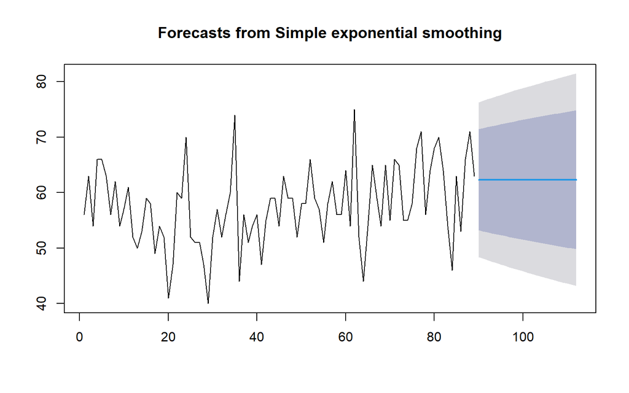

```r
ses.1 <- ses(train.ts, h = n_test, alpha = 0.2)
plot(ses.1)
```

Dibawah ini contoh inisialisasi nilai parameter $λ$ dengan nilai alpha 0,2 dan banyak periode data yang akan diramalkan adalah sebanyak n periode.

```r
# ramalan
ses.1
```

```
##     Point Forecast    Lo 80    Hi 80    Lo 95    Hi 95
##  90       62.33329 53.20649 71.46009 48.37505 76.29153
##  91       62.33329 53.02574 71.64084 48.09862 76.56796
##  92       62.33329 52.84844 71.81814 47.82746 76.83912
##  93       62.33329 52.67439 71.99219 47.56128 77.10530
##  94       62.33329 52.50342 72.16316 47.29980 77.36678
##  95       62.33329 52.33538 72.33120 47.04280 77.62378
##  96       62.33329 52.17011 72.49647 46.79005 77.87653
##  97       62.33329 52.00749 72.65909 46.54134 78.12524
##  98       62.33329 51.84739 72.81919 46.29649 78.37009
##  99       62.33329 51.68970 72.97688 46.05532 78.61126
## 100       62.33329 51.53431 73.13227 45.81768 78.84890
## 101       62.33329 51.38113 73.28545 45.58340 79.08318
## 102       62.33329 51.23005 73.43653 45.35236 79.31422
## 103       62.33329 51.08101 73.58557 45.12441 79.54217
## 104       62.33329 50.93392 73.73266 44.89945 79.76713
## 105       62.33329 50.78869 73.87788 44.67736 79.98922
## 106       62.33329 50.64528 74.02130 44.45802 80.20856
## 107       62.33329 50.50360 74.16298 44.24134 80.42524
## 108       62.33329 50.36360 74.30298 44.02723 80.63935
## 109       62.33329 50.22522 74.44136 43.81559 80.85099
## 110       62.33329 50.08840 74.57818 43.60634 81.06024
## 111       62.33329 49.95309 74.71349 43.39941 81.26717
## 112       62.33329 49.81925 74.84733 43.19471 81.47187
```

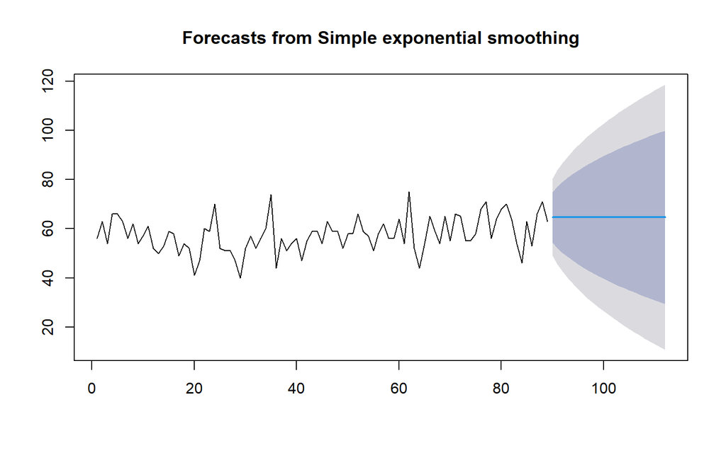

```r
ses.2<- ses(train.ts, h = n_test, alpha = 0.7)
plot(ses.2)
```

Dibawah ini contoh inisialisasi nilai parameter $λ$ dengan nilai alpha 0,7 dan banyak periode data yang akan diramalkan adalah sebanyak n periode.

```r
# ramalan
ses.2
```

```
##     Point Forecast    Lo 80    Hi 80    Lo 95     Hi 95
##  90       64.64703 54.36333 74.93073 48.91947  80.37459
##  91       64.64703 52.09418 77.19989 45.44910  83.84497
##  92       64.64703 50.17658 79.11748 42.51639  86.77767
##  93       64.64703 48.48493 80.80914 39.92923  89.36484
##  94       64.64703 46.95429 82.33978 37.58831  91.70575
##  95       64.64703 45.54591 83.74816 35.43438  93.85968
##  96       64.64703 44.23447 85.05959 33.42871  95.86535
##  97       64.64703 43.00235 86.29172 31.54434  97.74972
##  98       64.64703 41.83668 87.45738 29.76161  99.53245
##  99       64.64703 40.72776 88.56631 28.06566 101.22841
## 100       64.64703 39.66801 89.62605 26.44492 102.84915
## 101       64.64703 38.65143 90.64263 24.89019 104.40387
## 102       64.64703 37.67314 91.62092 23.39402 105.90004
## 103       64.64703 36.72911 92.56496 21.95025 107.34381
## 104       64.64703 35.81597 93.47810 20.55373 108.74034
## 105       64.64703 34.93088 94.36319 19.20009 110.09397
## 106       64.64703 34.07139 95.22267 17.88563 111.40844
## 107       64.64703 33.23542 96.05864 16.60712 112.68695
## 108       64.64703 32.42113 96.87294 15.36176 113.93230
## 109       64.64703 31.62691 97.66716 14.14711 115.14696
## 110       64.64703 30.85135 98.44272 12.96099 116.33307
## 111       64.64703 30.09319 99.20088 11.80149 117.49258
## 112       64.64703 29.35131 99.94275 10.66689 118.62718
```

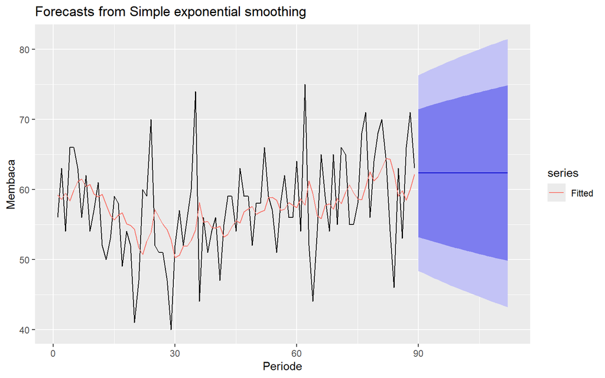

```r
autoplot(ses.1) +
  autolayer(fitted(ses.1), series="Fitted") +
  ylab("Membaca") + xlab("Periode")
```

Garis merah (fitted) menunjukkan hasil pemulusan dengan alpha=0,2 yang mengikuti pola data aktual namun dengan sedikit lag akibat pembobotan pada data historis. Hasil ramalan untuk periode ke depan berupa nilai konstan, sesuai dengan karakteristik SES yang mengasumsikan tidak adanya tren, dengan interval kepercayaan yang semakin melebar seiring bertambahnya horizon peramalan.

Untuk mendapatkan gambar hasil pemulusan pada data latih dengan fungsi ses() , perlu digunakan fungsi autoplot() dan autolayer() dari library packages ggplot2.

# Cara 2 fungsi HoltWinters

Fungsi HoltWinters memiliki argumen yang sama dengan fungsi ses().

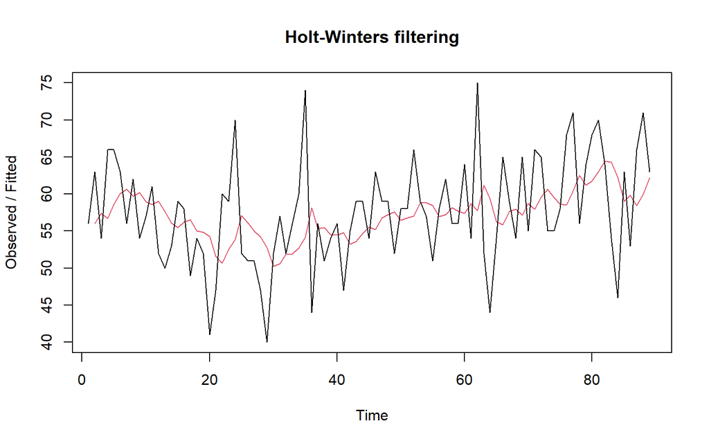

```r
ses1<- HoltWinters(train.ts, gamma = FALSE, beta = FALSE, alpha = 0.2)
plot(ses1)
```

```r
# ramalan
ramalan1 <- forecast(ses1, h=n_test)
ramalan1
```

```
##     Point Forecast    Lo 80    Hi 80    Lo 95    Hi 95
##  90       62.33329 53.18849 71.47809 48.34753 76.31905
##  91       62.33329 53.00739 71.65919 48.07056 76.59602
##  92       62.33329 52.82974 71.83684 47.79886 76.86772
##  93       62.33329 52.65534 72.01123 47.53215 77.13443
##  94       62.33329 52.48404 72.18254 47.27016 77.39642
##  95       62.33329 52.31567 72.35091 47.01266 77.65392
##  96       62.33329 52.15007 72.51651 46.75940 77.90717
##  97       62.33329 51.98713 72.67945 46.51021 78.15637
##  98       62.33329 51.82672 72.83986 46.26487 78.40171
##  99       62.33329 51.66871 72.99787 46.02323 78.64335
## 100       62.33329 51.51302 73.15356 45.78511 78.88147
## 101       62.33329 51.35953 73.30705 45.55038 79.11620
## 102       62.33329 51.20816 73.45842 45.31888 79.34770
## 103       62.33329 51.05883 73.60775 45.09048 79.57609
## 104       62.33329 50.91144 73.75514 44.86508 79.80150
## 105       62.33329 50.76593 73.90065 44.64254 80.02403
## 106       62.33329 50.62223 74.04435 44.42278 80.24380
## 107       62.33329 50.48028 74.18630 44.20567 80.46091
## 108       62.33329 50.34000 74.32658 43.99113 80.67544
## 109       62.33329 50.20134 74.46524 43.77908 80.88750
## 110       62.33329 50.06426 74.60232 43.56942 81.09716
## 111       62.33329 49.92868 74.73790 43.36208 81.30450
## 112       62.33329 49.79457 74.87201 43.15698 81.50960
```

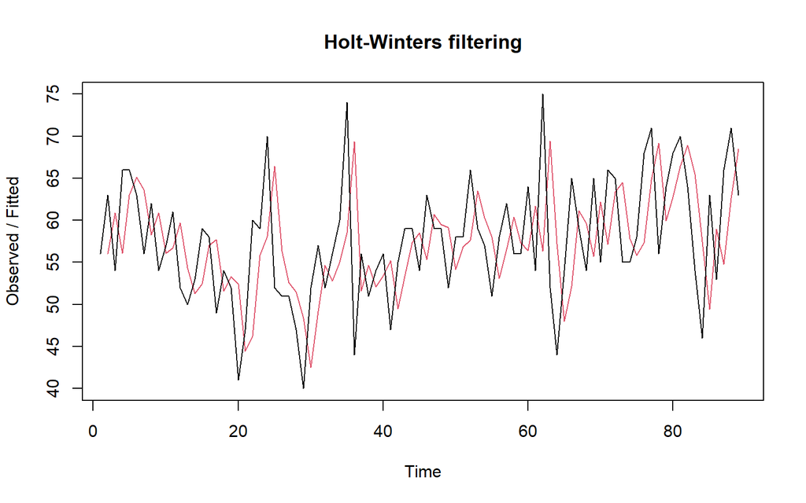

```r
ses2 <- HoltWinters(train.ts, gamma = FALSE, beta = FALSE, alpha = 0.7)
plot(ses2)
```

```r
# ramalan
ramalan2 <- forecast(ses2, h=n_test)
ramalan2
```

```
##     Point Forecast    Lo 80    Hi 80    Lo 95     Hi 95
##  90       64.64703 54.36233 74.93173 48.91794  80.37612
##  91       64.64703 52.09296 77.20111 45.44723  83.84683
##  92       64.64703 50.17518 79.11889 42.51424  86.77982
##  93       64.64703 48.48336 80.81070 39.92683  89.36724
##  94       64.64703 46.95257 82.34150 37.58568  91.70838
##  95       64.64703 45.54405 83.75001 35.43155  93.86252
##  96       64.64703 44.23249 85.06158 33.42568  95.86838
##  97       64.64703 43.00025 86.29382 31.54113  97.75293
##  98       64.64703 41.83447 87.45960 29.75823  99.53584
##  99       64.64703 40.72543 88.56863 28.06211 101.23196
## 100       64.64703 39.66559 89.62848 26.44121 102.85286
## 101       64.64703 38.64891 90.64516 24.88634 104.40773
## 102       64.64703 37.67052 91.62354 23.39002 105.90405
## 103       64.64703 36.72640 92.56767 21.94610 107.34796
## 104       64.64703 35.81317 93.48090 20.54944 108.74462
## 105       64.64703 34.92799 94.36607 19.19568 110.09838
## 106       64.64703 34.06843 95.22564 17.88109 111.41298
## 107       64.64703 33.23237 96.06169 16.60245 112.69161
## 108       64.64703 32.41800 96.87607 15.35698 113.93709
## 109       64.64703 31.62370 97.67036 14.14220 115.15186
## 110       64.64703 30.84806 98.44600 12.95597 116.33809
## 111       64.64703 30.08983 99.20423 11.79636 117.49771
## 112       64.64703 29.34789 99.94618 10.66165 118.63242
```

Nilai parameter $α$ dari kedua fungsi dapat dioptimalkan menyesuaikan dari error-nya paling minimumnya. Caranya adalah dengan membuat parameter $α$= NULL.

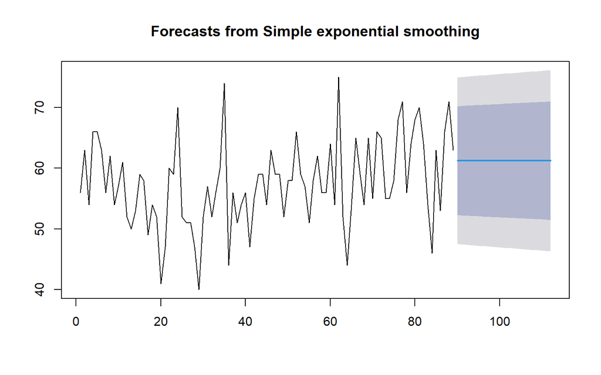

```r
# SES
ses.opt <- ses(train.ts, h = n_test, alpha = NULL)
plot(ses.opt)
```

```r
ses.opt
```

```
##     Point Forecast    Lo 80    Hi 80    Lo 95    Hi 95
##  90       61.24723 52.26557 70.22889 47.51096 74.98349
##  91       61.24723 52.22928 70.26518 47.45546 75.03899
##  92       61.24723 52.19314 70.30132 47.40019 75.09427
##  93       61.24723 52.15714 70.33732 47.34513 75.14932
##  94       61.24723 52.12128 70.37317 47.29029 75.20416
##  95       61.24723 52.08556 70.40889 47.23567 75.25878
##  96       61.24723 52.04999 70.44447 47.18126 75.31320
##  97       61.24723 52.01454 70.47991 47.12706 75.36740
##  98       61.24723 51.97924 70.51522 47.07306 75.42139
##  99       61.24723 51.94407 70.55039 47.01927 75.47518
## 100       61.24723 51.90903 70.58543 46.96569 75.52877
## 101       61.24723 51.87412 70.62033 46.91230 75.58216
## 102       61.24723 51.83934 70.65511 46.85911 75.63535
## 103       61.24723 51.80469 70.68976 46.80612 75.68834
## 104       61.24723 51.77017 70.72429 46.75332 75.74114
## 105       61.24723 51.73577 70.75868 46.70071 75.79375
## 106       61.24723 51.70150 70.79296 46.64829 75.84616
## 107       61.24723 51.66734 70.82711 46.59606 75.89839
## 108       61.24723 51.63331 70.86114 46.54402 75.95044
## 109       61.24723 51.59940 70.89505 46.49215 76.00230
## 110       61.24723 51.56561 70.92884 46.44047 76.05398
## 111       61.24723 51.53194 70.96252 46.38897 76.10548
## 112       61.24723 51.49838 70.99607 46.33765 76.15680
```

```r
# Lamda Optimum Holt-Winter
HWopt<- HoltWinters(train.ts, gamma = FALSE, beta = FALSE,alpha = NULL)
HWopt
```

```
## Holt-Winters exponential smoothing without trend and without seasonal component.
##
## Call:
## HoltWinters(x = train.ts, alpha = NULL, beta = FALSE, gamma = FALSE)
##
## Smoothing parameters:
##  alpha: 0.08394696
##  beta : FALSE
##  gamma: FALSE
##
## Coefficients:
##       [,1]
## a 61.13374
```

Hasil pencarian parameter optimum menggunakan fungsi `HoltWinters()` menghasilkan nilai alpha optimum sebesar 0,084, yang berarti bobot dominan diberikan pada data historis (bukan data terbaru) karena karakteristik data yang stasioner tanpa tren. Nilai koefisien level (a) sebesar 61,13 menunjukkan estimasi level data pada akhir periode data latih, yang akan digunakan sebagai dasar peramalan periode berikutnya.

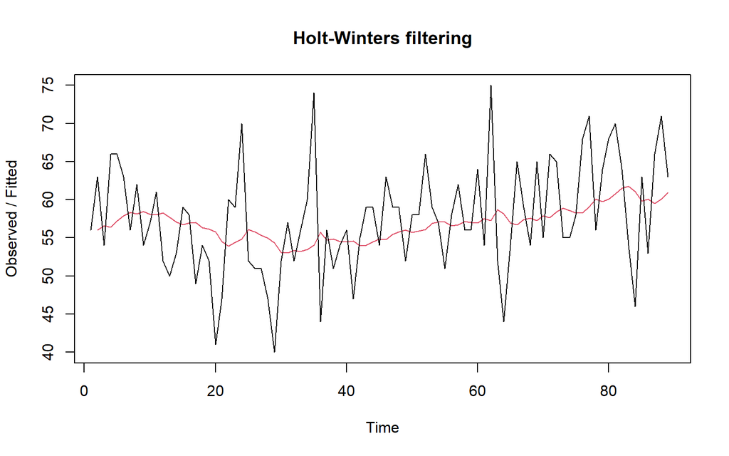

```r
plot(HWopt)
```

```r
# ramalan
ramalanopt<- forecast(HWopt, h=n_test)
ramalanopt
```

```
##     Point Forecast    Lo 80    Hi 80    Lo 95    Hi 95
##  90       61.13374 52.18161 70.08588 47.44264 74.82485
##  91       61.13374 52.15012 70.11737 47.39448 74.87301
##  92       61.13374 52.11874 70.14874 47.34649 74.92100
##  93       61.13374 52.08748 70.18001 47.29867 74.96882
##  94       61.13374 52.05631 70.21117 47.25101 75.01647
##  95       61.13374 52.02526 70.24223 47.20352 75.06397
##  96       61.13374 51.99431 70.27318 47.15619 75.11130
##  97       61.13374 51.96347 70.30402 47.10901 75.15847
##  98       61.13374 51.93272 70.33476 47.06200 75.20549
##  99       61.13374 51.90209 70.36540 47.01514 75.25235
## 100       61.13374 51.87155 70.39594 46.96844 75.29905
## 101       61.13374 51.84111 70.42638 46.92189 75.34560
## 102       61.13374 51.81077 70.45672 46.87549 75.39200
## 103       61.13374 51.78053 70.48696 46.82924 75.43825
## 104       61.13374 51.75039 70.51710 46.78314 75.48434
## 105       61.13374 51.72035 70.54714 46.73719 75.53029
## 106       61.13374 51.69040 70.57709 46.69139 75.57610
## 107       61.13374 51.66054 70.60695 46.64573 75.62176
## 108       61.13374 51.63078 70.63671 46.60021 75.66728
## 109       61.13374 51.60111 70.66638 46.55484 75.71265
## 110       61.13374 51.57153 70.69595 46.50960 75.75788
## 111       61.13374 51.54205 70.72544 46.46451 75.80298
## 112       61.13374 51.51265 70.75483 46.41956 75.84793
```

## Akurasi Data Latih

Perhitungan akurasi data dapat dilakukan dengan cara langsung maupun manual. Secara langsung, nilai akurasi dapat diambil dari objek yang tersimpan pada hasil SES, yaitu sum of squared errors (SSE).

### Cara Langsung

```r
# SES dengan alpha = 0.2
SSE1<-ses1$SSE
MSE1<-ses1$SSE/length(train.ts)
RMSE1<-sqrt(MSE1)

akurasi1 <- matrix(c(SSE1,MSE1,RMSE1))
row.names(akurasi1)<- c("SSE", "MSE", "RMSE")
colnames(akurasi1) <- c("Akurasi alpha = 0.2")
akurasi1
```

```
##      Akurasi alpha = 0.2
## SSE           4441.30940
## MSE             49.90235
## RMSE             7.06416
```

Nilai RMSE menunjukkan bahwa rata-rata simpangan hasil pemulusan terhadap data aktual sekitar 7,06 satuan PM10 yang tergolong cukup kecil, sehingga model SES dengan $α$ = 0,2 dapat dikategorikan memiliki tingkat akurasi yang baik pada data latih.

```r
# SES dengan alpha = 0.7
SSE2<-ses2$SSE
MSE2<-ses2$SSE/length(train.ts)
RMSE2<-sqrt(MSE2)

akurasi2 <- matrix(c(SSE2,MSE2,RMSE2))
row.names(akurasi2)<- c("SSE", "MSE", "RMSE")
colnames(akurasi2) <- c("Akurasi alpha = 0.7")
akurasi2
```

```
##      Akurasi alpha = 0.7
## SSE          5604.857583
## MSE            62.975928
## RMSE            7.935737
```

Dibandingkan dengan $α$ =0,2, seluruh nilai akurasi pada $α$= 0,7 lebih besar (SSE, MSE, dan RMSE meningkat), yang menunjukkan bahwa model dengan $α$ =0,2 memberikan hasil pemulusan yang lebih baik pada data latih dibandingkan $α$ =0,7.

```r
SSE1<-ses1$SSE
SSE1
```

```
## [1] 4441.309
```

Nilai SSE sebesar 4441,309 ini diperoleh langsung dari komponen SSE pada objek hasil HoltWinters(), yang menunjukkan hasil yang konsisten dengan perhitungan akurasi pada tabel sebelumnya.

### Cara Manual

```r
# alpha = 0.2
fitted1<-ramalan1$fitted
sisaan1<-ramalan1$residuals
head(sisaan1)
```

```
## Time Series:
## Start = 1
## End = 6
## Frequency = 1
## [1]      NA  7.0000 -3.4000  9.2800  7.4240  2.9392
```

```r
resid1<-training$pm10-ramalan1$fitted
head(resid1)
```

```
## Time Series:
## Start = 1
## End = 6
## Frequency = 1
## [1]      NA  7.0000 -3.4000  9.2800  7.4240  2.9392
```

```r
SSE.1=sum(sisaan1[2:length(train.ts)]^2)
SSE.1
```

```
## [1] 4441.309
```

```r
MSE.1 = SSE.1/length(train.ts)
MSE.1
```

```
## [1] 49.90235
```

```r
MAPE.1 = sum(abs(sisaan1[2:length(train.ts)]/train.ts[2:length(train.ts)])*100)/length(train.ts)
MAPE.1
```

```
## [1] 9.986011
```

```r
akurasi.1 <- matrix(c(SSE.1,MSE.1,MAPE.1))
row.names(akurasi.1)<- c("SSE", "MSE", "MAPE")
colnames(akurasi.1) <- c("Akurasi alpha = 0.2")
akurasi.1
```

```
##      Akurasi alpha = 0.2
## SSE          4441.309404
## MSE            49.902353
## MAPE            9.986011
```

```r
# alpha = 0.7
fitted2<-ramalan2$fitted
sisaan2<-ramalan2$residuals
head(sisaan2)
```

```
## Time Series:
## Start = 1
## End = 6
## Frequency = 1
## [1]      NA  7.0000 -6.9000  9.9300  2.9790 -2.1063
```

```r
resid2<-training$pm10-ramalan2$fitted
head(resid2)
```

```
## Time Series:
## Start = 1
## End = 6
## Frequency = 1
## [1]      NA  7.0000 -6.9000  9.9300  2.9790 -2.1063
```

```r
SSE.2=sum(sisaan2[2:length(train.ts)]^2)
SSE.2
```

```
## [1] 5604.858
```

```r
MSE.2 = SSE.2/length(train.ts)
MSE.2
```

```
## [1] 62.97593
```

```r
MAPE.2 = sum(abs(sisaan2[2:length(train.ts)]/train.ts[2:length(train.ts)])*100)/length(train.ts)
MAPE.2
```

```
## [1] 11.56164
```

```r
akurasi.2 <- matrix(c(SSE.2,MSE.2,MAPE.2))
row.names(akurasi.2)<- c("SSE", "MSE", "MAPE")
colnames(akurasi.2) <- c("Akurasi alpha = 0.7")
akurasi.2
```

```
##      Akurasi alpha = 0.7
## SSE           5604.85758
## MSE             62.97593
## MAPE            11.56164
```

Berdasarkan nilai SSE, MSE, RMSE, dan MAPE di antara kedua parameter, nilai parameter $α$ =0,2 menghasilkan akurasi yang lebih baik dibanding $α$ =0,7. Hal ini dilihat dari nilai masing-masing ukuran akurasi yang lebih kecil. Berdasarkan nilai MAPE-nya, hasil ini dapat dikategorikan sebagai peramalan sangat baik.

## Akurasi Data Uji

Perhitungan akurasi data dapat dilakukan dengan cara langsung maupun manual. Secara langsung, nilai akurasi dapat diambil dari objek yang tersimpan pada hasil SES, yaitu sum of squared errors (SSE).

```r
# jumlah observasi uji
n_test <- nrow(testing)

# error (ramalan - aktual), samakan panjang dan tipe numeric
e1   <- as.numeric(ramalan1$mean)[1:n_test] - as.numeric(testing$pm10)
e2   <- as.numeric(ramalan2$mean)[1:n_test] - as.numeric(testing$pm10)
eopt <- as.numeric(ramalanopt$mean)[1:n_test] - as.numeric(testing$pm10)

# SSE / MSE / RMSE untuk masing-masing model (abaikan NA)
SSEtesting1  <- sum(e1^2,  na.rm = TRUE)
MSEtesting1  <- mean(e1^2, na.rm = TRUE)
RMSEtesting1 <- sqrt(MSEtesting1)

SSEtesting2  <- sum(e2^2,  na.rm = TRUE)
MSEtesting2  <- mean(e2^2, na.rm = TRUE)
RMSEtesting2 <- sqrt(MSEtesting2)

SSEtestingopt  <- sum(eopt^2,  na.rm = TRUE)
MSEtestingopt  <- mean(eopt^2, na.rm = TRUE)
RMSEtestingopt <- sqrt(MSEtestingopt)

# Tabel ringkas
akurasitesting_SSE <- matrix(c(SSEtesting1, SSEtesting2, SSEtestingopt),nrow = 3, dimnames = list(c("SSE1","SSE2","SSEopt"), "Nilai"))
akurasitesting_MSE <- matrix(c(MSEtesting1, MSEtesting2, MSEtestingopt),nrow = 3,dimnames = list(c("MSE1","MSE2","MSEopt"), "Nilai"))
akurasitesting_RMSE <- matrix(c(RMSEtesting1, RMSEtesting2, RMSEtestingopt), nrow = 3, dimnames = list(c("RMSE1","RMSE2","RMSEopt"), "Nilai"))

akurasitesting_SSE
```

```
##           Nilai
## SSE1   1859.547
## SSE2   2448.504
## SSEopt 1651.136
```

```r
akurasitesting_MSE
```

```
##            Nilai
## MSE1    80.84986
## MSE2   106.45670
## MSEopt  71.78850
```

```r
akurasitesting_RMSE
```

```
##             Nilai
## RMSE1    8.991655
## RMSE2   10.317785
## RMSEopt  8.472810
```

Selain dengan cara di atas, perhitungan nilai akurasi dapat menggunakan fungsi accuracy() dari package forecast.

```r
library (forecast)
```

```r
ramalan1 <- forecast(ses1, h = n_test)
ramalan2 <- forecast(ses2, h = n_test)
ramalanopt <- forecast(HWopt, h = n_test)
```

```r
accuracy(ramalan1, testing$pm10)
```

```
##                     ME     RMSE      MAE        MPE     MAPE      MASE
## Training set  0.359846 7.104184 5.701499 -0.8021087 10.09949 0.8053482
## Test set     -4.376768 8.991655 8.086939 -9.4269555 14.67740 1.1422964
##                   ACF1
## Training set 0.0578981
## Test set            NA
```

```r
accuracy(ramalan2, testing$pm10)
```

```
##                      ME      RMSE      MAE        MPE     MAPE      MASE
## Training set  0.1403739  7.980699 6.583633  -1.056483 11.69302 0.9299513
## Test set     -6.6905107 10.317785 9.135537 -13.488763 16.90202 1.2904130
##                    ACF1
## Training set -0.2240842
## Test set             NA
```

```r
accuracy(ramalanopt, testing$pm10)
```

```
##                      ME     RMSE      MAE        MPE      MAPE      MASE
## Training set  0.6949388 6.980263 5.600463 -0.2582701  9.874178 0.7910767
## Test set     -3.1772222 8.472810 7.617552 -7.3211364 13.641920 1.0759945
##                   ACF1
## Training set 0.1229217
## Test set            NA
```

# Double Exponential Smoothing (DES)

Metode pemulusan Double Exponential Smoothing (DES) digunakan untuk data yang memiliki pola tren. Metode DES adalah metode semacam SES, hanya saja dilakukan dua kali, yaitu pertama untuk tahapan ‘level’ dan kedua untuk tahapan ‘tren’. Pemulusan menggunakan metode ini akan menghasilkan peramalan tidak konstan untuk periode berikutnya.

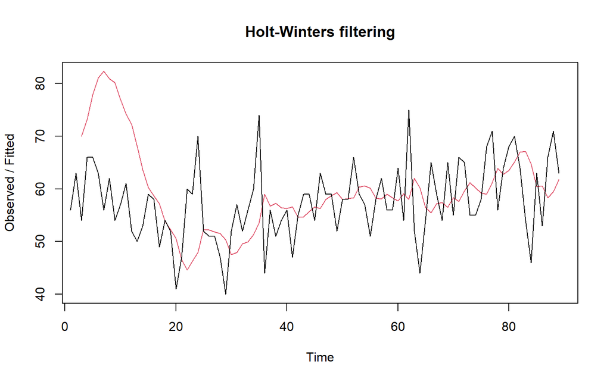

```r
# alpha = 0.2 dan beta = 0.2
des.1<- HoltWinters(train.ts, gamma = FALSE, beta = 0.2, alpha = 0.2)
plot(des.1)
```

```r
# ramalan
ramalandes1<- forecast(des.1, h=n_test)
ramalandes1
```

```
##     Point Forecast    Lo 80     Hi 80     Lo 95     Hi 95
##  90       62.14414 49.60014  74.68815 42.959746  81.32854
##  91       62.24258 49.34237  75.14279 42.513410  81.97175
##  92       62.34102 48.97121  75.71083 41.893658  82.78838
##  93       62.43946 48.48007  76.39886 41.090408  83.78851
##  94       62.53790 47.86624  77.20956 40.099536  84.97626
##  95       62.63634 47.13041  78.14227 38.922066  86.35061
##  96       62.73478 46.27582  79.19373 37.562978  87.90658
##  97       62.83322 45.30749  80.35894 36.029931  89.63650
##  98       62.93166 44.23141  81.63190 34.332103  91.53121
##  99       63.03010 43.05399  83.00620 32.479283  93.58091
## 100       63.12853 41.78161  84.47546 30.481224  95.77585
## 101       63.22697 40.42034  86.03361 28.347230  98.10672
## 102       63.32541 38.97583  87.67500 26.085935 100.56489
## 103       63.42385 37.45322  89.39448 23.705202 103.14250
## 104       63.52229 35.85715  91.18743 21.212107 105.83248
## 105       63.62073 34.19174  93.04972 18.612976 108.62849
## 106       63.71917 32.46068  94.97766 15.913441 111.52490
## 107       63.81761 30.66725  96.96797 13.118509 114.51671
## 108       63.91605 28.81435  99.01774 10.232637 117.59946
## 109       64.01449 26.90459 101.12439  7.259793 120.76918
## 110       64.11293 24.94027 103.28558  4.203525 124.02233
## 111       64.21137 22.92349 105.49924  1.067011 127.35572
## 112       64.30981 20.85611 107.76350 -2.146893 130.76650
```

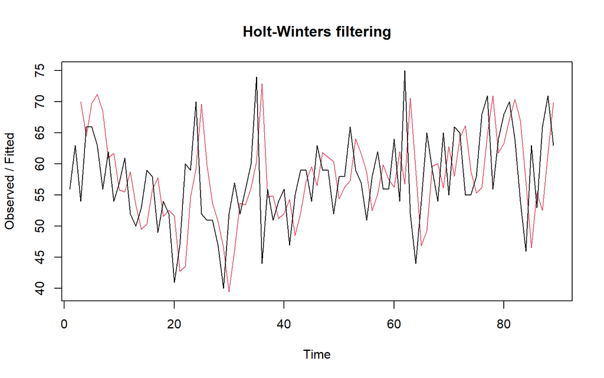

```r
# alpha = 0.6 dan beta = 0.3
des.2<- HoltWinters(train.ts, gamma = FALSE, beta = 0.3, alpha = 0.6)
plot(des.2)
```

```r
# ramalan
ramalandes2<- forecast(des.2, h=n_test)
ramalandes2
```

```
##     Point Forecast      Lo 80     Hi 80       Lo 95     Hi 95
##  90       67.20489  55.777769  78.63201   49.728616  84.68116
##  91       68.64042  54.148233  83.13260   46.476534  90.80430
##  92       70.07595  51.899998  88.25190   42.278231  97.87366
##  93       71.51148  49.149326  93.87362   37.311519 105.71143
##  94       72.94700  45.973188  99.92082   31.694112 114.19990
##  95       74.38253  42.423344 106.34172   25.505171 123.25989
##  96       75.81806  38.536213 113.09991   18.800395 132.83573
##  97       77.25359  34.338701 120.16848   11.620931 142.88625
##  98       78.68912  29.851574 127.52666    3.998540 153.37969
##  99       80.12465  25.091459 135.15783   -4.041351 164.29064
## 100       81.56017  20.072067 143.04828  -12.477770 175.59812
## 101       82.99570  14.804985 151.18642  -21.293001 187.28441
## 102       84.43123   9.300190 159.56227  -30.471781 199.33424
## 103       85.86676   3.566414 168.16711  -40.000757 211.73428
## 104       87.30229  -2.388604 176.99318  -49.868094 224.47267
## 105       88.73782  -8.557931 186.03356  -60.063189 237.53882
## 106       90.17334 -14.935302 195.28199  -70.576459 250.92315
## 107       91.60887 -21.515010 204.73276  -81.399177 264.61692
## 108       93.04440 -28.291826 214.38063  -92.523346 278.61215
## 109       94.47993 -35.260930 224.22079 -103.941592 292.90145
## 110       95.91546 -42.417857 234.24877 -115.647090 307.47801
## 111       97.35099 -49.758455 244.46043 -127.633489 322.33546
## 112       98.78652 -57.278847 254.85188 -139.894860 337.46789
```

## Perbandingan Plot Data Latih dan Data Uji

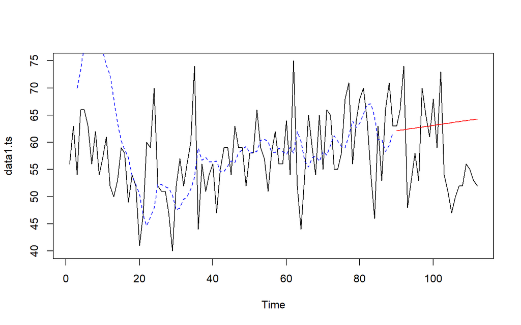

```r
plot(data1.ts)
lines(des.1$fitted[,1], lty=2, col="blue")
lines(ramalandes1$mean, col="red")
```

Untuk mendapatkan nilai parameter optimum dari DES, argumen alpha dan beta dapat dibuat NULL seperti berikut ini.

```r
# alpha dan beta optimum
des.opt<- HoltWinters(train.ts, gamma = FALSE)
des.opt
```

```
## Holt-Winters exponential smoothing with trend and without seasonal component.
##
## Call:
## HoltWinters(x = train.ts, gamma = FALSE)
##
## Smoothing parameters:
##  alpha: 0.485212
##  beta : 0.1716539
##  gamma: FALSE
##
## Coefficients:
##         [,1]
## a 64.5865517
## b  0.6674437
```

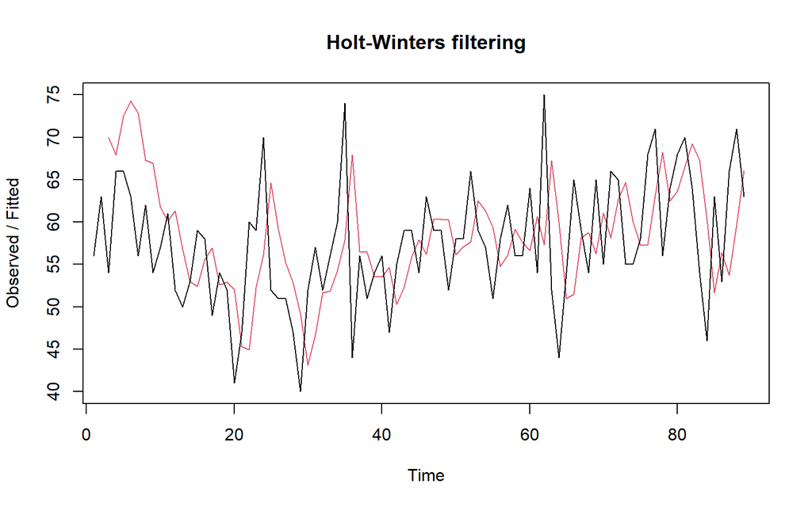

```r
plot(des.opt)
```

```r
# ramalan
ramalandesopt<- forecast(des.opt, h=n_test)
ramalandesopt
```

```
##     Point Forecast      Lo 80     Hi 80         Lo 95     Hi 95
##  90       65.25400 54.2989746  76.20902  48.499736947  82.00825
##  91       65.92144 53.3198656  78.52301  46.648995620  85.19388
##  92       66.58888 52.1049457  81.07282  44.437612655  88.74015
##  93       67.25633 50.6843059  83.82835  41.911608248  92.60104
##  94       67.92377 49.0821408  86.76540  39.107984709  96.73956
##  95       68.59121 47.3174064  89.86502  36.055733076 101.12669
##  96       69.25866 45.4049248  93.11239  32.777521470 105.73979
##  97       69.92610 43.3563986  96.49580  29.291247677 110.56095
##  98       70.59354 41.1812086 100.00588  25.611258349 115.57583
##  99       71.26099 38.8870036 103.63497  21.749251339 120.77273
## 100       71.92843 36.4801281 107.37674  17.714929522 126.14193
## 101       72.59588 33.9659306 111.22582  13.516472932 131.67528
## 102       73.26332 31.3489882 115.17765   9.160881603 137.36576
## 103       73.93076 28.6332709 119.22826   4.654227073 143.20730
## 104       74.59821 25.8222637 123.37415   0.001839182 149.19457
## 105       75.26565 22.9190586 127.61224  -4.791553285 155.32285
## 106       75.93309 19.9264246 131.93976  -9.721715270 161.58790
## 107       76.60054 16.8468625 136.35421 -14.784822400 167.98590
## 108       77.26798 13.6826469 140.85332 -19.977395905 174.51336
## 109       77.93543 10.4358602 145.43499 -25.296250968 181.16710
## 110       78.60287  7.1084199 150.09732 -30.738455244 187.94419
## 111       79.27031  3.7021000 154.83852 -36.301295170 194.84192
## 112       79.93776  0.2185501 159.65696 -41.982248328 201.85776
```

## Akurasi Data Latih

```r
# akurasi data training
ssedes.train1<-des.1$SSE
msedes.train1<-ssedes.train1/length(train.ts)
sisaandes1<-ramalandes1$residuals
head(sisaandes1)
```

```
## Time Series:
## Start = 1
## End = 6
## Frequency = 1
## [1]        NA        NA -16.00000  -7.16000 -11.80160 -18.04282
```

```r
mapedes.train1 <- sum(abs(sisaandes1[3:length(train.ts)]/train.ts[3:length(train.ts)]) *100)/length(train.ts)

akurasides.1 <- matrix(c(ssedes.train1,msedes.train1,mapedes.train1))
row.names(akurasides.1)<- c("SSE", "MSE", "MAPE")
colnames(akurasides.1) <- c("Akurasi alpha = 0.2 dan beta = 0.2")
akurasides.1
```

```
##      Akurasi alpha = 0.2 dan beta = 0.2
## SSE                          8581.63666
## MSE                            96.42288
## MAPE                           12.89646
```

```r
ssedes.train2<-des.2$SSE
msedes.train2<-ssedes.train2/length(train.ts)
sisaandes2<-ramalandes2$residuals
head(sisaandes2)
```

```
## Time Series:
## Start = 1
## End = 6
## Frequency = 1
## [1]         NA         NA -16.000000   1.480000  -3.794400  -8.221168
```

```r
mapedes.train2 <- sum(abs(sisaandes2[3:length(train.ts)]/train.ts[3:length(train.ts)]) *100)/length(train.ts)

akurasides.2 <- matrix(c(ssedes.train2,msedes.train2,mapedes.train2))
row.names(akurasides.2)<- c("SSE", "MSE", "MAPE")
colnames(akurasides.2) <- c("Akurasi alpha = 0.6 dan beta = 0.3")
akurasides.2
```

```
##      Akurasi alpha = 0.6 dan beta = 0.3
## SSE                          6848.52574
## MSE                            76.94973
## MAPE                           12.52468
```

## Akurasi Data Uji

```r
# akurasi data testing
selisihdes1<-ramalandes1$mean-testing$pm10
selisihdes1
```

```
## Time Series:
## Start = 90
## End = 112
## Frequency = 1
##  [1]  -0.8558575  -3.7574182 -11.6589790  14.4394602   9.5378994   4.6363387
##  [7]   9.7347779  -7.1667829  -2.0683437   2.0300955  -4.8714652   4.2269740
## [13]  -9.6745868   9.4238524  12.5222917  16.6207309  13.7191701  11.8176093
## [19]  11.9160486   8.0144878   9.1129270  11.2113662  12.3098054
```

```r
SSEtestingdes1<-sum(selisihdes1^2)
MSEtestingdes1<-SSEtestingdes1/length(testing$pm10)
MAPEtestingdes1<-sum(abs(selisihdes1/testing$pm10)*100)/length(testing$pm10)

selisihdes2<-ramalandes2$mean-testing$pm10
selisihdes2
```

```
## Time Series:
## Start = 90
## End = 112
## Frequency = 1
##  [1]  4.204890  2.640418 -3.924053 23.511475 19.947004 16.382532 22.818060
##  [8]  7.253589 13.689117 19.124646 13.560174 23.995703 11.431231 31.866759
## [15] 36.302288 41.737816 40.173345 39.608873 41.044402 38.479930 40.915458
## [22] 44.350987 46.786515
```

```r
SSEtestingdes2<-sum(selisihdes2^2)
MSEtestingdes2<-SSEtestingdes2/length(testing$pm10)
MAPEtestingdes2<-sum(abs(selisihdes2/testing$pm10)*100)/length(testing$pm10)

selisihdesopt<-ramalandesopt$mean-testing$pm10
selisihdesopt
```

```
## Time Series:
## Start = 90
## End = 112
## Frequency = 1
##  [1]  2.25399537 -0.07856096 -7.41111729 19.25632638 14.92377005 10.59121372
##  [7] 16.25865739 -0.07389894  5.59354473 10.26098840  3.92843207 13.59587573
## [13]  0.26331940 19.93076307 23.59820674 28.26565041 25.93309408 24.60053775
## [19] 25.26798142 21.93542509 23.60286876 26.27031243 27.93775610
```

```r
SSEtestingdesopt<-sum(selisihdesopt^2)
MSEtestingdesopt<-SSEtestingdesopt/length(testing$pm10)
MAPEtestingdesopt<-sum(abs(selisihdesopt/testing$pm10)*100)/length(testing$pm10)

akurasitestingdes <- matrix(c(SSEtestingdes1,MSEtestingdes1,MAPEtestingdes1,SSEtestingdes2,MSEtestingdes2,MAPEtestingdes2,SSEtestingdesopt,MSEtestingdesopt,MAPEtestingdesopt),nrow=3,ncol=3)
row.names(akurasitestingdes)<- c("SSE", "MSE", "MAPE")
colnames(akurasitestingdes) <- c("des ske1","des ske2","des opt")
akurasitestingdes
```

```
##       des ske1    des ske2    des opt
## SSE  2177.7045 19529.44137 7545.13113
## MSE    94.6828   849.10615  328.04918
## MAPE   15.9883    47.13686   28.78709
```

# Perbandingan SES dan DES

```r
MSEfull <- matrix(c(MSEtesting1,MSEtesting2,MSEtestingopt,MSEtestingdes1,MSEtestingdes2,MSEtestingdesopt),nrow=3,ncol=2)
row.names(MSEfull)<- c("ske 1", "ske 2", "ske opt")
colnames(MSEfull) <- c("ses","des")
MSEfull
```

```
##               ses      des
## ske 1    80.84986  94.6828
## ske 2   106.45670 849.1061
## ske opt  71.78850 328.0492
```

Kedua metode dapat dibandingkan dengan menggunakan ukuran akurasi yang sama. Contoh di atas adalah perbandingan kedua metode dengan ukuran akurasi MSE. asilnya menunjukkan bahwa metode SES lebih baik dibandingkan metode DES, dilihat dari nilai MSE yang secara konsisten lebih kecil. Hal ini sejalan dengan karakteristik data PM10 yang bersifat stasioner tanpa pola tren yang jelas, sehingga **metode SES (yang hanya memodelkan komponen level) lebih sesuai** dibandingkan DES (yang turut memodelkan komponen tren yang sebenarnya tidak dominan pada data ini).

# Pemulusan Data Musiman (Holt-Winters)

# Data

## Impor Data

```r
data2 <- read.csv("ispu_anggota_3.csv")
data2.ts <- ts(data2$pm10)
```

## Membagi Data

```r
# n, n_train, n_test didefinisikan di section sebelumnya (SES)
fq <- 7  # asumsi pola mingguan untuk data harian; sesuaikan kalau ada alasan lain

training <- data2[1:n_train, "pm10"]
testing  <- data2[(n_train+1):n, "pm10"]
training.ts <- ts(training, frequency = fq)
testing.ts  <- ts(testing, frequency = fq)
```

## Eksplorasi Data

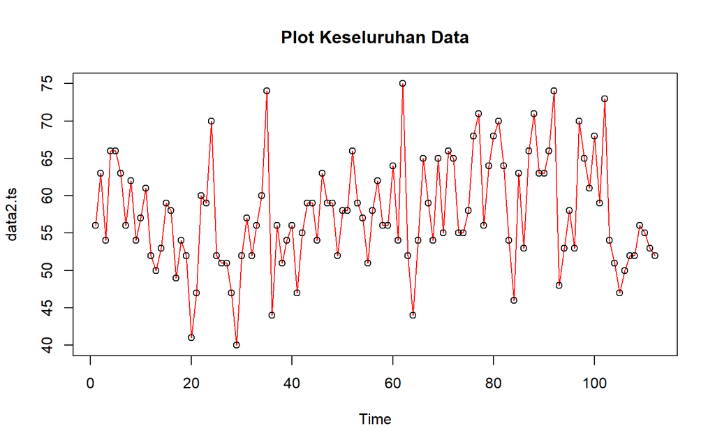

```r
# plot time series
plot(data2.ts, col="red",main="Plot Keseluruhan Data")
points(data2.ts)
```

Data PM10 secara keseluruhan menunjukkan pola fluktuatif di kisaran 40–75 tanpa tren atau pola musiman yang mencolok secara visual.

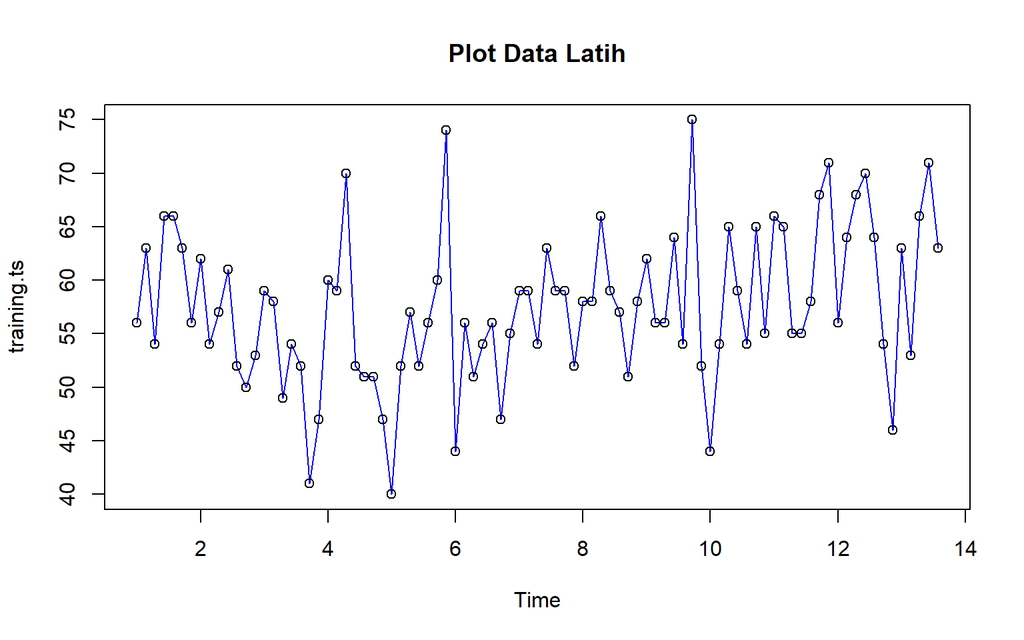

```r
plot(training.ts, col="blue", main="Plot Data Latih")
points(training.ts)
```

Data latih (89 observasi) menunjukkan pola yang sama, yaitu fluktuatif tanpa tren yang jelas. Pada plot ini ditampilkan dalam satuan “siklus” (bukan urutan hari), karena efek dari penetapan frequency = 7 (asumsi pola mingguan) pada objek time series.

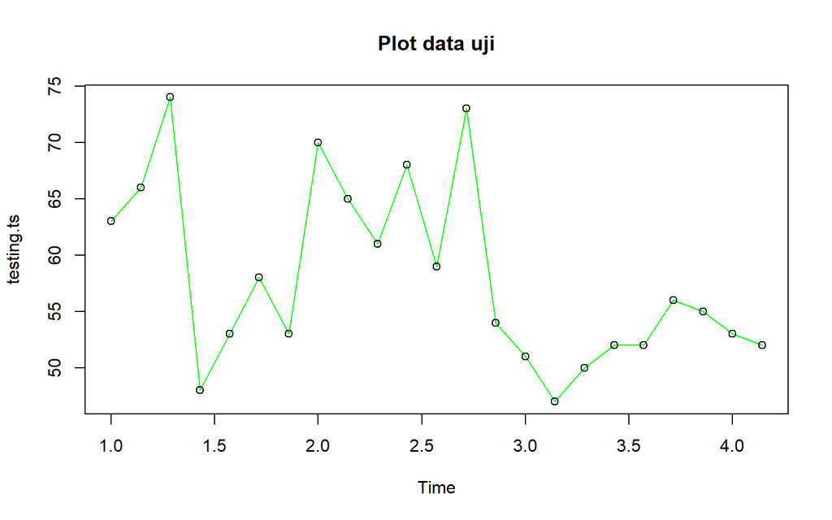

```r
plot(testing.ts, col="green", main="Plot data uji")
points(testing.ts)
```

Data uji (23 observasi) juga menunjukkan pola fluktuatif yang serupa dengan data latih, mengindikasikan pembagian data yang representatif untuk evaluasi model Holt-Winters musiman.

Metode Holt-Winter untuk peramalan data musiman menggunakan tiga persamaan pemulusan yang terdiri atas persamaan untuk level ($L_t$), trend ($B_t$), dan komponen seasonal/musiman ($S_t$) dengan parameter pemulusan berupa $α$, $β$, dan $γ$. Metode Holt-Winter musiman terbagi menjadi dua, yaitu metode aditif dan metode multiplikatif.

# Winter Aditif

Perhitungan dengan model aditif dilakukan jika plot data asli menunjukkan fluktuasi musiman yang relatif stabil (konstan).

## Pemulusan

```r
winter1 <- HoltWinters(training.ts, alpha=0.2, beta=0.1, gamma=0.1, seasonal = "additive")
winter1$fitted
```

```
## Time Series:
## Start = c(2, 1)
## End = c(13, 5)
## Frequency = 7
##               xhat    level       trend      season
##  2.000000 62.96599 62.73469 -0.82993197  1.06122449
##  2.142857 55.92354 61.71156 -0.84925170 -4.93877551
##  2.285714 59.50825 60.47761 -0.88772245 -0.08163265
##  2.428571 62.49728 59.08823 -0.93788746  4.34693878
##  2.571429 60.37285 57.85089 -0.96783314  3.48979592
##  2.714286 55.84871 55.20849 -1.13529017  1.77551020
##  2.857143 45.99813 52.90345 -1.25226427 -5.65306122
##  3.000000 52.92328 53.05156 -1.11222684  0.98394558
##  3.142857 47.07133 53.15468 -0.99069250 -5.09265850
##  3.285714 53.29531 54.34972 -0.77211909 -0.28229268
##  3.428571 56.08767 52.71854 -0.85802530  4.22715604
##  3.571429 53.36317 51.44298 -0.89977873  2.81996781
##  3.714286 50.65114 50.27057 -0.92704214  1.30761379
##  3.857143 41.20032 47.41330 -1.12006495 -5.09291150
##  4.000000 47.91918 47.45317 -1.00407139  1.47008296
##  4.142857 43.88444 48.86526 -0.76245500 -4.21836487
##  4.285714 50.03986 51.12592 -0.46014383 -0.62591751
##  4.428571 58.65700 54.65780 -0.06094097  4.06014230
##  4.571429 55.78229 53.26546 -0.19408105  2.71091417
##  4.714286 52.36072 52.11492 -0.28972694  0.53552257
##  4.857143 46.60717 51.55305 -0.31694128 -4.62893726
##  5.000000 53.44214 51.31468 -0.30908473  2.43654851
##  5.142857 44.73011 48.31716 -0.57792750 -3.00912021
##  5.285714 49.73158 49.19321 -0.43252980  0.97089394
##  5.428571 53.45479 50.21437 -0.28716133  3.52758195
##  5.571429 51.64832 49.63625 -0.31625708  2.32833063
##  5.714286 50.38777 50.19033 -0.22922352  0.42666522
##  5.857143 47.24906 51.88355 -0.03697889 -4.59751105
##  6.000000 59.05598 57.19676  0.49803992  1.36117739
##  6.142857 52.45299 54.68360  0.19692040 -2.42752940
##  6.285714 57.41015 55.58992  0.26786051  1.55236783
##  6.428571 58.12661 54.57575  0.13965744  3.41119893
##  6.571429 56.62368 53.89009  0.05712522  2.67646489
##  6.714286 55.06277 53.82248  0.04465162  1.19564374
##  6.857143 49.68054 52.25458 -0.11660388 -2.45743582
```

[output cut: 32 more lines]

```
## 11.571429 59.61060 58.33917  0.01710300  1.25432724
## 11.714286 60.03438 58.03416 -0.01510907  2.01533437
## 11.857143 57.12967 59.61217  0.14420332 -2.62670477
## 12.000000 63.21723 62.53044  0.42160995  0.26517809
## 12.142857 60.73539 61.50860  0.27726539 -1.05048159
## 12.285714 63.80585 62.43879  0.34255763  1.02450273
## 12.428571 66.55260 63.62018  0.42644059  2.50598380
## 12.571429 66.35697 64.73610  0.49538852  1.12547899
## 12.714286 67.86093 64.76009  0.44824919  2.65258392
## 12.857143 61.09011 62.43616  0.17103064 -1.51707826
## 13.000000 59.14619 59.58917 -0.13077156 -0.31220013
## 13.142857 59.38615 60.22916 -0.05369546 -0.78931262
## 13.285714 60.07685 58.89823 -0.18141842  1.36003454
## 13.428571 62.62026 59.90144 -0.06295536  2.78177552
## 13.571429 62.55600 61.51444  0.10463937  0.93692167
```

```r
xhat1 <- winter1$fitted[,2]
winter1.opt <- HoltWinters(training.ts, alpha=NULL, beta=NULL, gamma=NULL, seasonal = "additive")

winter1.opt$fitted
```

```
## Time Series:
## Start = c(2, 1)
## End = c(13, 5)
## Frequency = 7
##               xhat    level        trend      season
##  2.000000 62.96599 62.73469 -0.829931973  1.06122449
##  2.142857 56.01302 61.79983 -0.848034791 -4.93877551
##  2.285714 59.76573 60.73312 -0.885759199 -0.08163265
##  2.428571 62.95627 59.54692 -0.937589556  4.34693878
##  2.571429 60.91236 58.39682 -0.974250442  3.48979592
##  2.714286 57.08865 56.45441 -1.141270261  1.77551020
##  2.857143 47.61593 54.54310 -1.274113335 -5.65306122
##  3.000000 53.66155 53.85386 -1.173214487  0.98090768
##  3.142857 47.08125 53.26056 -1.073170723 -5.10614747
##  3.285714 52.19336 53.37350 -0.868550629 -0.31158851
##  3.428571 55.41394 52.15805 -0.928394997  4.18428535
##  3.571429 52.86995 51.07606 -0.954892660  2.74877874
##  3.714286 50.24160 50.02667 -0.971195697  1.18612506
##  3.857143 41.70176 48.05155 -1.144385433 -5.20540310
##  4.000000 47.86239 47.48272 -1.045095225  1.42477206
##  4.142857 42.74019 47.75613 -0.817633556 -4.19830907
##  4.285714 47.61479 48.70481 -0.512920820 -0.57710014
##  4.428571 54.59691 50.62360 -0.093416548  4.06672311
##  4.571429 52.78245 50.24808 -0.142083226  2.67644702
##  4.714286 50.15462 49.91237 -0.175486684  0.41773380
##  4.857143 44.90419 49.82872 -0.159644021 -4.76488202
##  5.000000 52.21033 49.89674 -0.120368078  2.43395172
##  5.142857 45.25438 48.44996 -0.349192535 -2.84638944
##  5.285714 49.89489 48.83355 -0.222778001  1.28411533
##  5.428571 53.14378 49.38260 -0.089626458  3.85080356
##  5.571429 51.58591 49.16873 -0.111061152  2.52824583
##  5.714286 49.99685 49.53717 -0.028340060  0.48802298
##  5.857143 46.16397 50.59547  0.159121343 -4.59062637
##  6.000000 55.87793 53.77843  0.680775268  1.41872577
##  6.142857 51.34156 53.16890  0.458179916 -2.28552582
##  6.285714 56.55348 54.13313  0.545480232  1.87486906
##  6.428571 58.27245 54.07534  0.441406645  3.75570421
##  6.571429 57.30922 54.05263  0.361339959  2.89525467
##  6.714286 55.92828 54.27174  0.336804860  1.31973338
##  6.857143 51.53195 53.63867  0.169486693 -2.27620332
```

[output cut: 32 more lines]

```
## 11.571429 59.44337 58.25635 -0.026403497  1.21341977
## 11.714286 59.89787 58.07315 -0.053452556  1.87817014
## 11.857143 56.32979 58.89984  0.098383277 -2.66843550
## 12.000000 61.24315 60.59185  0.373306615  0.27799295
## 12.142857 59.66640 60.39559  0.275048685 -1.00423978
## 12.285714 62.71624 61.14140  0.356261348  1.21857586
## 12.428571 65.17645 62.07164  0.455280291  2.64953302
## 12.571429 64.68999 63.05090  0.545674711  1.09341116
## 12.714286 66.60619 63.52163  0.532744131  2.55182049
## 12.857143 61.53277 62.68495  0.296501098 -1.44868256
## 13.000000 61.14159 61.29413  0.005413185 -0.15794821
## 13.142857 60.89773 61.50142  0.040240233 -0.64392339
## 13.285714 62.23385 60.68372 -0.107765224  1.65789341
## 13.428571 63.99848 60.98508 -0.037186719  3.05058613
## 13.571429 62.83853 61.70847  0.094023515  1.03604202
```

```r
xhat1.opt <- winter1.opt$fitted[,2]
```

## Peramalan

```r
forecast1 <- predict(winter1, n.ahead = n_test)
forecast1.opt <- predict(winter1.opt, n.ahead = n_test)
```

## Plot Deret Waktu

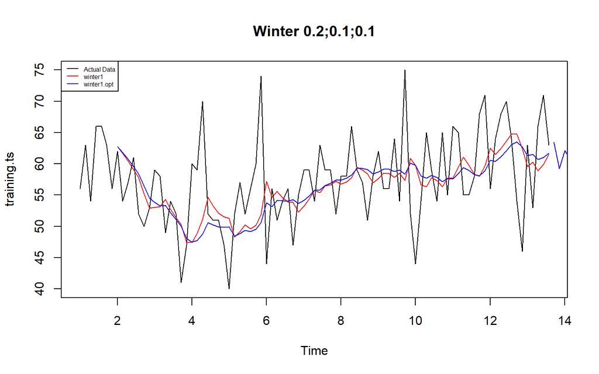

```r
plot(training.ts, main="Winter 0.2;0.1;0.1", type="l", col="black", pch=12)
lines(xhat1, type="l", col="red")
lines(xhat1.opt, type="l", col="blue")
lines(forecast1, type="l", col="red")
lines(forecast1.opt, type="l", col="blue")
legend("topleft", c("Actual Data","winter1","winter1.opt"), cex=0.5,
       col=c("black","red","blue"), lty=1)
```

Garis merah (winter1, parameter manual) dan garis biru (winter1.opt, parameter optimal) menunjukkan hasil pemulusan yang hampir berimpit satu sama lain, terlihat bahwa hasil pemulusan Winter Aditif ini cenderung lebih halus (smooth) dibandingkan data aktual, sesuai dengan **sifat metode ini yang meredam fluktuasi tajam melalui kombinasi komponen level, tren, dan musiman**.

## Akurasi Data Latih

```r
# akurasi data training
SSE1<-winter1$SSE
MSE1<-winter1$SSE/length(training.ts)
RMSE1<-sqrt(MSE1)
akurasi1 <- matrix(c(SSE1,MSE1,RMSE1))
row.names(akurasi1)<- c("SSE", "MSE", "RMSE")
colnames(akurasi1) <- c("Akurasi")
akurasi1
```

```
##          Akurasi
## SSE  5195.678074
## MSE    58.378405
## RMSE    7.640576
```

```r
SSE1.opt<-winter1.opt$SSE
MSE1.opt<-winter1.opt$SSE/length(training.ts)
RMSE1.opt<-sqrt(MSE1.opt)
akurasi1.opt <- matrix(c(SSE1.opt,MSE1.opt,RMSE1.opt))
row.names(akurasi1.opt)<- c("SSE1.opt", "MSE1.opt", "RMSE1.opt")
colnames(akurasi1.opt) <- c("Akurasi")
akurasi1.opt
```

```
##               Akurasi
## SSE1.opt  5066.542192
## MSE1.opt    56.927440
## RMSE1.opt    7.545028
```

```r
akurasi1.train = data.frame(Model_Winter = c("Winter 1","Winter1 optimal"),Nilai_SSE=c(SSE1,SSE1.opt),
                            Nilai_MSE=c(MSE1,MSE1.opt),Nilai_RMSE=c(RMSE1,RMSE1.opt))
akurasi1.train
```

```
##      Model_Winter Nilai_SSE Nilai_MSE Nilai_RMSE
## 1        Winter 1  5195.678  58.37841   7.640576
## 2 Winter1 optimal  5066.542  56.92744   7.545028
```

Perbandingan ini menunjukkan bahwa parameter optimal memberikan hasil pemulusan yang sedikit lebih akurat dibandingkan parameter manual pada data latih, meskipun selisihnya tidak terlalu besar.

## Akurasi Data Uji

```r
# akurasi data testing
forecast1 <- data.frame(forecast1)
testing.ts <- data.frame(testing.ts)

selisih1<-forecast1-testing.ts
SSEtesting1 <- sum(selisih1^2)
MSEtesting1 <- SSEtesting1/n_test

forecast1.opt <- data.frame(forecast1.opt)
selisih1.opt <- forecast1.opt-testing.ts
SSEtesting1.opt <- sum(selisih1.opt^2)
MSEtesting1.opt<-SSEtesting1.opt/n_test
```

```r
akurasi_testing <- data.frame(
  Model = c("Model1", "Model Optimum"),
  SSE   = c(SSEtesting1, SSEtesting1.opt),
  MSE   = c(MSEtesting1, MSEtesting1.opt)
)
akurasi_testing
```

```
##           Model      SSE      MSE
## 1        Model1 2287.172 99.44227
## 2 Model Optimum 2258.929 98.21428
```

# Winter Multiplikatif

Model multiplikatif digunakan cocok digunakan jika plot data asli menunjukkan fluktuasi musiman yang bervariasi.

## Pemulusan

```r
winter2 <- HoltWinters(training.ts,alpha=0.2,beta=0.1,gamma=0.3,seasonal = "multiplicative")
winter2$fitted
```

```
## Time Series:
## Start = c(2, 1)
## End = c(13, 5)
## Frequency = 7
##               xhat    level        trend    season
##  2.000000 62.97746 62.73469 -0.829931973 1.0173281
##  2.142857 55.79287 61.71260 -0.849148113 0.9166892
##  2.285714 59.56649 60.47229 -0.888264333 0.9997057
##  2.428571 62.44146 59.07058 -0.939609274 1.0741514
##  2.571429 60.04012 57.86258 -0.966448311 1.0552585
##  2.714286 55.81738 55.37231 -1.118830393 1.0288258
##  2.857143 47.11888 53.12260 -1.231918084 0.9080412
##  3.000000 52.78817 53.18602 -1.102383831 1.0135268
##  3.142857 47.59765 53.30943 -0.979805262 0.9095737
##  3.285714 53.28831 54.61692 -0.751075045 0.9892782
##  3.428571 55.71708 52.99889 -0.837770802 1.0681726
##  3.571429 52.01001 51.83962 -0.869920620 1.0204102
##  3.714286 50.22506 50.96774 -0.870116722 1.0025437
##  3.857143 44.11509 48.25729 -1.054149776 0.9345796
##  4.000000 48.77112 47.82051 -0.992412772 1.0414926
##  4.142857 46.05198 48.98441 -0.776782247 0.9552842
##  4.285714 48.89326 50.91844 -0.505700215 0.9698591
##  4.428571 57.98873 54.76528 -0.070446372 1.0602231
##  4.571429 54.46873 53.56512 -0.183417447 1.0203631
##  4.714286 50.17743 52.70181 -0.251407478 0.9566644
##  4.857143 49.71941 52.62237 -0.234210831 0.9490582
##  5.000000 56.49603 51.81508 -0.291518386 1.0965087
##  5.142857 48.70412 48.51473 -0.592401243 1.0163136
##  5.285714 51.03918 48.57093 -0.527541729 1.0623560
##  5.428571 50.37804 49.16557 -0.415322769 1.0333904
##  5.571429 48.90254 49.06416 -0.383931795 1.0045668
##  5.714286 47.87735 50.09327 -0.242627971 0.9604160
##  5.857143 49.05650 52.37510  0.009817850 0.9364623
##  6.000000 59.12283 57.71209  0.542535493 1.0149036
##  6.142857 57.32888 55.27448  0.244520326 1.0325993
##  6.285714 60.55427 55.26161  0.218781797 1.0914535
##  6.428571 55.99551 53.72965  0.043707560 1.0413243
##  6.571429 55.45500 53.39010  0.005381260 1.0385712
##  6.714286 54.37074 53.50043  0.015876391 1.0159659
##  6.857143 54.02350 52.06532 -0.129221833 1.0401917
```

[output cut: 32 more lines]

```
## 11.571429 57.49783 57.72922  0.027432359 0.9955188
## 11.714286 62.38578 57.85754  0.037520912 1.0775666
## 11.857143 57.43572 58.93708  0.141722691 0.9721884
## 12.000000 62.28618 61.86926  0.420768981 0.9999382
## 12.142857 62.93473 61.03272  0.295037520 1.0262031
## 12.285714 63.78482 61.53537  0.315798831 1.0312631
## 12.428571 64.94405 62.66865  0.397546670 1.0297761
## 12.571429 64.38910 64.04814  0.495741718 0.9976018
## 12.714286 71.47703 64.46588  0.487941077 1.1004285
## 12.857143 63.48440 61.77741  0.170300593 1.0248062
## 13.000000 56.91822 58.53548 -0.170922989 0.9752190
## 13.142857 61.37391 59.61182 -0.046196570 1.0303579
## 13.285714 60.46825 57.94019 -0.208740270 1.0474058
## 13.428571 61.54382 58.78772 -0.103112638 1.0487216
## 13.571429 60.33223 60.48798  0.077224680 0.9961533
```

```r
xhat2 <- winter2$fitted[,2]

winter2.opt<- HoltWinters(training.ts, alpha= NULL,  beta = NULL, gamma = NULL, seasonal = "multiplicative")
winter2.opt$fitted
```

```
## Time Series:
## Start = c(2, 1)
## End = c(13, 5)
## Frequency = 7
##               xhat    level       trend    season
##  2.000000 62.97746 62.73469 -0.82993197 1.0173281
##  2.142857 55.87607 61.80019 -0.84598143 0.9166892
##  2.285714 59.83368 60.73147 -0.88016759 0.9997057
##  2.428571 62.96168 59.54280 -0.92751581 1.0741514
##  2.571429 60.63356 58.41651 -0.95802199 1.0552585
##  2.714286 57.07242 56.56804 -1.09468642 1.0288258
##  2.857143 48.59442 54.72518 -1.20951508 0.9080412
##  3.000000 53.77644 54.04371 -1.12847099 1.0162752
##  3.142857 47.95606 53.47466 -1.04261330 0.9146326
##  3.285714 52.58534 53.62723 -0.85917846 0.9965374
##  3.428571 55.15778 52.37648 -0.91927654 1.0719157
##  3.571429 52.67535 51.33964 -0.93731880 1.0450977
##  3.714286 50.38252 50.33199 -0.94811321 1.0202220
##  3.857143 43.18989 48.38295 -1.10173369 0.9134683
##  4.000000 47.76694 47.73518 -1.03206012 1.0227784
##  4.142857 43.73381 48.00489 -0.83226828 0.9271016
##  4.285714 48.01937 48.96480 -0.55720811 0.9919801
##  4.428571 54.19742 50.81925 -0.18707198 1.0704144
##  4.571429 52.40589 50.40875 -0.22136332 1.0442044
##  4.714286 50.16110 50.04085 -0.24385340 1.0073116
##  4.857143 45.62461 49.88764 -0.22994196 0.9187822
##  5.000000 51.58760 49.82063 -0.20493630 1.0397436
##  5.142857 45.50822 48.40273 -0.39109846 0.9478582
##  5.285714 49.48756 48.75705 -0.27669354 1.0207755
##  5.428571 52.44431 49.28135 -0.15375862 1.0675123
##  5.571429 50.99263 49.08229 -0.16071102 1.0423340
##  5.714286 49.78017 49.44444 -0.08046430 1.0084312
##  5.857143 46.54268 50.46698  0.08882198 0.9206201
##  6.000000 55.68364 53.80186  0.58701995 1.0238056
##  6.142857 51.22600 53.14683  0.39639271 0.9567224
##  6.285714 56.25347 54.08632  0.47974569 1.0309241
##  6.428571 58.04635 54.01144  0.39462332 1.0669096
##  6.571429 56.99060 53.99328  0.33127137 1.0490762
##  6.714286 55.73235 54.22179  0.31549835 1.0219129
##  6.857143 51.33819 53.60725  0.17275964 0.9545960
```

[output cut: 32 more lines]

```
## 11.571429 59.95081 58.48696 -0.01736942 1.0253332
## 11.714286 59.82501 58.26251 -0.04915091 1.0276852
## 11.857143 56.25216 59.07914  0.08372659 0.9508019
## 12.000000 61.56407 60.85104  0.34282376 1.0060498
## 12.142857 59.38216 60.59192  0.25043958 0.9760003
## 12.285714 62.97261 61.35732  0.32947338 1.0208444
## 12.428571 65.75775 62.22279  0.41173686 1.0498644
## 12.571429 65.02189 63.07431  0.47923425 1.0231041
## 12.714286 66.26540 63.44483  0.46254991 1.0368974
## 12.857143 60.80574 62.61995  0.26495749 0.9669369
## 13.000000 61.22367 61.21839  0.00918356 0.9999363
## 13.142857 60.29270 61.42091  0.03885752 0.9810108
## 13.285714 62.15360 60.65069 -0.08531882 1.0262234
## 13.428571 64.26277 60.97330 -0.02270979 1.0543421
## 13.571429 63.09012 61.64606  0.08402938 1.0220318
```

```r
xhat2.opt <- winter2.opt$fitted[,2]
```

## Peramalan

```r
forecast2 <- predict(winter2, n.ahead = n_test)
forecast2.opt <- predict(winter2.opt, n.ahead = n_test)
```

## Plot Deret Waktu

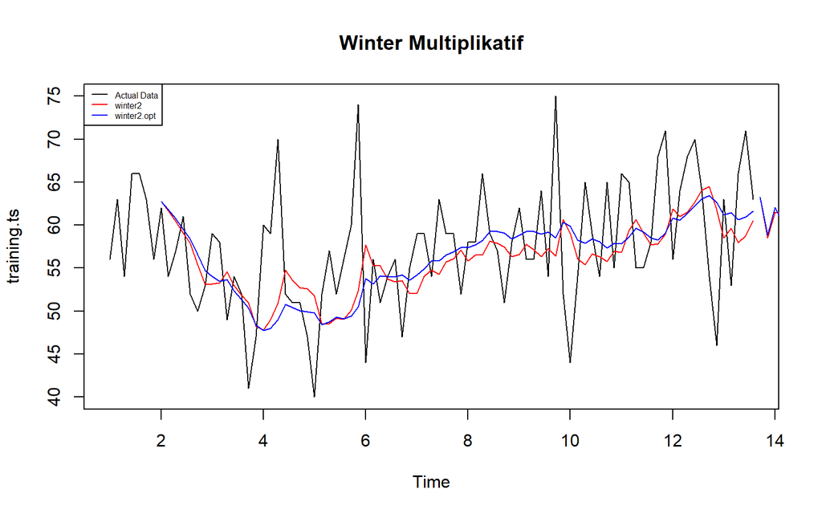

```r
plot(training.ts, main="Winter Multiplikatif", type="l", col="black", pch=12)
lines(xhat2, type="l", col="red")
lines(xhat2.opt, type="l", col="blue")
lines(forecast2, type="l", col="red")
lines(forecast2.opt, type="l", col="blue")
legend("topleft", c("Actual Data","winter2","winter2.opt"), cex=0.5,
       col=c("black","red","blue"), lty=1)
```

## Akurasi Data Latih

```r
# akurasi data training
SSE2<-winter2$SSE
MSE2<-winter2$SSE/length(training.ts)
RMSE2<-sqrt(MSE2)
akurasi1 <- matrix(c(SSE2,MSE2,RMSE2))
row.names(akurasi1)<- c("SSE2", "MSE2", "RMSE2")
colnames(akurasi1) <- c("Akurasi Winter 2 (alpha=0.2, beta=0.1, gamma=0.3)")
akurasi1
```

```
##       Akurasi Winter 2 (alpha=0.2, beta=0.1, gamma=0.3)
## SSE2                                        5604.654685
## MSE2                                          62.973648
## RMSE2                                          7.935594
```

Nilai ini menunjukkan tingkat kesalahan pemulusan yang relatif tinggi, dan akan dibandingkan dengan hasil parameter optimal pada tahap selanjutnya untuk menentukan model terbaik.

```r
SSE2.opt<-winter2.opt$SSE
MSE2.opt<-winter2.opt$SSE/length(training.ts)
RMSE2.opt<-sqrt(MSE2.opt)
akurasi1.opt <- matrix(c(SSE2.opt,MSE2.opt,RMSE2.opt))
row.names(akurasi1.opt)<- c("SSE2.opt", "MSE2.opt", "RMSE2.opt")
colnames(akurasi1.opt) <- c("Akurasi")
akurasi1.opt
```

```
##               Akurasi
## SSE2.opt  4894.090382
## MSE2.opt    54.989780
## RMSE2.opt    7.415509
```

Nilai ini lebih kecil dibandingkan parameter manual (SSE=5604,65; MSE=62,97; RMSE=7,94).

```r
akurasi2.train = data.frame(Model_Winter = c("Winter 2","Winter 2 optimal"),Nilai_SSE=c(SSE2,SSE2.opt),
                            Nilai_MSE=c(MSE2,MSE2.opt),Nilai_RMSE=c(RMSE2,RMSE2.opt))
akurasi2.train
```

```
##       Model_Winter Nilai_SSE Nilai_MSE Nilai_RMSE
## 1         Winter 2  5604.655  62.97365   7.935594
## 2 Winter 2 optimal  4894.090  54.98978   7.415509
```

Perbandingan ini menunjukkan bahwa parameter optimal memberikan hasil pemulusan yang lebih akurat pada data latih untuk model Winter Multiplikatif.

## Akurasi Data Uji

```r
# akurasi data testing
forecast2<-data.frame(forecast2)
testing.ts<-data.frame(testing.ts)
selisih2<-forecast2-testing.ts
SSEtesting2<-sum(selisih2^2)
MSEtesting2<-SSEtesting2/n_test

forecast2.opt<-data.frame(forecast2.opt)
selisih2.opt<-forecast2.opt-testing.ts
SSEtesting2.opt<-sum(selisih2.opt^2)
MSEtesting2.opt<-SSEtesting2.opt/n_test
```

```r
# rapikan dalam tabel
akurasi_testing2 <- data.frame(
  Model = c("Model2", "Model2 Optimal"),
  SSE   = c(SSEtesting2, SSEtesting2.opt),
  MSE   = c(MSEtesting2, MSEtesting2.opt)
)

akurasi_testing2
```

```
##            Model      SSE       MSE
## 1         Model2 2459.918 106.95294
## 2 Model2 Optimal 2175.464  94.58537
```

Perbandingan ini menunjukkan bahwa parameter optimal juga memberikan performa peramalan yang lebih baik pada data uji, konsisten dengan hasil pada data latih.

# Kesimpulan

Berdasarkan eksplorasi awal, data menunjukkan pola fluktuatif di kisaran 40–75 tanpa tren jangka panjang maupun pola musiman yang mencolok, sehingga data ini bersifat relatif stasioner. Data kemudian dibagi menjadi 89 observasi data latih (80%) dan 23 observasi data uji (20%) untuk membangun dan mengevaluasi lima metode pemulusan: SMA, DMA, SES, DES, dan Holt-Winters (aditif & multiplikatif).

Hasil evaluasi menunjukkan metode **Double Moving Average (DMA) dengan m=7 memberikan kinerja terbaik dengan nilai MAPE data uji sebesar 9,82%**, yang termasuk kategori sangat baik. Hasil ini menunjukkan bahwa metode berbasis rata-rata bergerak lebih sesuai untuk data PM10 yang relatif stasioner dan tidak memiliki pola tren maupun musiman yang kuat. Sebaliknya, metode DES dan Holt-Winters menghasilkan tingkat kesalahan yang lebih besar karena kurang sesuai dengan karakteristik data.